# Su et al., (2024): No effect of partial reinforcement on fear extinction learning and memory in C57BL/6J mice

Su CJ, Fukunaga Y, Penna SR, Cazares VA

2024-05-05

# Load packages

```r
library(tidyverse)
library(kableExtra)
library(afex)
library(emmeans)
library(pwr2)
library(rstatix)
library(viridis)
```

# Fig 1. Testing the effect of partial reinforcement in extinction learning:

To characterize the partial reinforcement extinction effect in fear learning, we exposed mice to consistent reinforcement (3:3, CS:US pairs; 100% contingency) or partial reinforcement (6:3, CS:US pairs; 50% contingency) for two days followed by extinction training across three days, and recall tests at 48 hours and 30 days after the last day of extinction (Fig. 1A). Mice received CS durations of either 10 or 25 seconds during the two-day fear conditioning (FC) protocol.

# Load and tidy data

Data was exported from VideoFreeze as CSV files. The header rows of the raw CSV files contain information regarding how the data was exported (ie how data was segmented into bins as well as what motion index threshold was used as a cut-off for assessing freezing).

```r
# df ---------------------------------------------------

list.files(path="./Figure_1_2_PREE", pattern=".csv$", recursive = TRUE)
list.filenames <- list.files(path="./Figure_1_2_PREE", pattern = ".csv$",
                             full.names=TRUE, recursive = TRUE)
# delete the metadata from the list.filenames
list.filenames <- list.filenames[!(str_detect(list.filenames, "metadata"))]
list.filenames
metadata <- read.csv("./Figure_1_2_PREE/metadata.csv")
list.data <- list()

for (i in 1:length(list.filenames)) {
  list.data[[i]] <- read.csv(list.filenames[[i]], skip=
                               ifelse(str_detect(list.filenames[[i]], "FC\\w*03.csv$"), 15,
                                      ifelse(str_detect(list.filenames[[i]], "FC\\w*06.csv$"), 18,
                                             ifelse(str_detect(list.filenames[[i]], "FC\\w*12.csv$"), 24,
                                                    ifelse(str_detect(list.filenames[[i]], "ER"), 16,
                                                           ifelse(str_detect(list.filenames[[i]], "SR"), 16,
                                                                  24)))))
  )
  list.data[[i]]$ExpDetails <- str_sub(list.filenames[[i]], 38
                                       , -5)
  #remove the first and last characters
  list.data[[i]] <- dplyr::select(list.data[[i]], -c(Animal, Group))
}

list.data <- list.data %>%
  reduce(full_join) %>% #collapse separate items in list into one
  separate(col=ExpDetails, into = c("Exp_Date", "Exp_Type"), sep = "_")
# Conver list into a dataframe
df<-as.data.frame(list.data)
# Join df and metadata
df<- full_join(df, metadata,  by= c("Exp_Type", "Exp_Date", "Box", "Trial"))
#change name L1 to 1
df$Animal[df$Animal == "L1"] <- "1"
df$Animal[df$Animal == "L2"] <- "2"
df$Animal[df$Animal == "R1"] <- "3"
df$Animal[df$Animal == "R2"] <- "4"

df<- df%>%
  mutate(id= paste(Group, Cage, Animal, sep="_")) %>%
  mutate(Trial=as.factor(Trial)) %>%
  mutate(CS_Time=as.factor(CS_Time)) %>%
  filter(str_detect(id, "3CS_CSUS_100_30_2|6CS_CSUS_50_26_2", negate = TRUE),
         str_detect(Tx,  "SCFE"),
         str_detect(Group, "3CS_USCS_50", negate = TRUE)) %>%
  mutate(Contingency=ifelse(
    str_detect(Group, "50"), "50%",
    ifelse(str_detect(Group, "100"),"100%", NA
    ))) %>%
  mutate(Trials=ifelse(
    str_detect(Group, "12CS_CSUS_50|6CS_CSUS_100"), "6 Trials",
    ifelse(str_detect(Group, "6CS_CSUS_50|3CS_CSUS_100"), "3 Trials", NA
    )))

rm(list=setdiff(ls(), "df"))
df<- df %>%
  drop_na(Trial, Strain, Experiment)

#write_csv(df, "220803_PREE_df.csv")
```

## B. Fear Acquisition——————–

Compare the average percent time freezing during CS presentations across the two days of FC training

### B - Dataframe

```r
FC_id_1 <- df %>%
  filter(str_detect(Component.Name, "pre-tone|post-tone", negate = TRUE),
         str_detect(Exp_Type, "FC"),
         str_detect(Trials, "3 Trials")) %>%
  group_by(id, Group, CS_Time, Contingency) %>%
  summarize(mean_freezing=mean(Pct.Component.Time.Freezing), n=n(),
            se=sd(Pct.Component.Time.Freezing/sqrt(n())))
#write_csv(FC_id, "220803_PREE_FC_id.csv")

FC_ave_1 <- FC_id_1 %>%
  group_by(CS_Time, Group, Contingency) %>%
  summarize(group_mean_freezing=mean(mean_freezing), n=n(),
            se=sd(mean_freezing/sqrt(n())))
#write_csv(FC_ave, "220803_PREE_FC_ave.csv")
```

### B - Graph

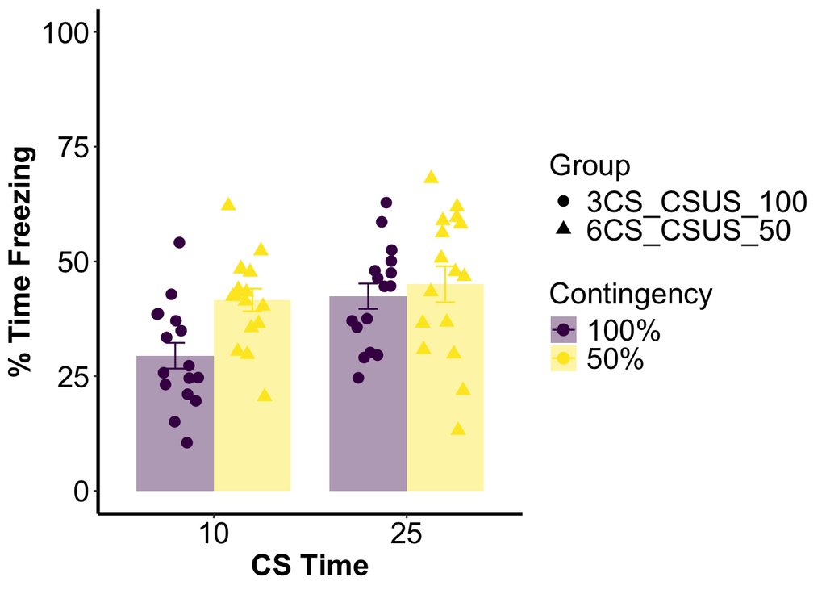

```r
ggplot(FC_ave_1,
       aes(x=CS_Time,
           y=group_mean_freezing,
           group=Contingency,
           color=Contingency,
           fill=Contingency,
           shape=Group)) +
  scale_fill_viridis(discrete = TRUE) +
  scale_colour_viridis(discrete = TRUE) +
  geom_bar(
    stat = "identity",
    position = "dodge",
    width=0.8,
    alpha=0.4,
    color=NA) +
  geom_errorbar(
    aes(
      ymin = group_mean_freezing-se,
      ymax = group_mean_freezing+se,
      width = .2),
    position=position_dodge(width=0.8)
  ) +
  geom_point(
    data=FC_id_1,
    aes(x=CS_Time, y=mean_freezing),
    position = position_jitterdodge(jitter.height=0, jitter.width=0.25,
                                    dodge.width = 0.8),
    size=3
  ) +
  ylim(0,100) +
  theme_bw() +
  theme(legend.text=element_text(size=18),
        legend.title = element_text(size=18),
        panel.border= element_blank(),
        plot.background = element_blank(),
        plot.title = element_text(size = 18,face="bold.italic", hjust=0.5),
        panel.grid.major = element_blank(),
        panel.grid.minor = element_blank(),
        axis.text.x = element_text(size = 18, color="black"),
        axis.text.y = element_text(size = 18, color="black"),
        axis.title.x = element_text(size = 18, face= "bold"),
        axis.title.y = element_text(size = 18, face="bold"),
        axis.line.x = element_line(color="black", linewidth = 1),
        axis.line.y = element_line(color="black", linewidth = 1),
        strip.text = element_text(size = 18)) +
  labs(
    x = "CS Time",
    y = "% Time Freezing")
```

### B - Stats

Sex was originally in the statistical model: mean_freezing ~ Contingency (2) X CS_time (2) X Sex (2). However, considering lack of sex-specific effects in any of our experiments, it was dropped from models.

```r
m1b <- FC_id_1 %>%
  aov_ez(id = "id",
         dv = "mean_freezing",
         between = c("Contingency", "CS_Time"),
         data = .)
```

```
## Converting to factor: Contingency
```

```
## Contrasts set to contr.sum for the following variables: Contingency, CS_Time
```

```r
#ANOVA table
nice_m1b <-nice(m1b)
kable(nice_m1b, caption = '<b>Figure 1B: Main FX</b>') %>%
  kable_styling(bootstrap_options = "striped", full_width = F, position = "left")
```

**Figure 1B: Main FX**

| Effect | df | MSE | F | ges | p.value |
| --- | --- | --- | --- | --- | --- |
| Contingency | 1, 60 | 147.62 | 5.92 * | .090 | .018 |
| CS_Time | 1, 60 | 147.62 | 7.29 ** | .108 | .009 |
| Contingency:CS_Time | 1, 60 | 147.62 | 2.46 | .039 | .122 |

```r
n1b <- emmeans(m1b, ~ Contingency * CS_Time)
n1b
```

```
##  Contingency CS_Time emmean   SE df lower.CL upper.CL
##  100%        10        29.4 3.04 60     23.4     35.5
##  50%         10        41.6 3.04 60     35.5     47.7
##  100%        25        42.4 3.04 60     36.3     48.5
##  50%         25        45.0 3.04 60     39.0     51.1
##
## Confidence level used: 0.95
```

```r
n1b_pairs<- pairs(n1b, simple="each")

#Simple contrasts for contingency
kable(n1b_pairs[1], caption = '<b>Figure 1B: Simple contrasts for contingency</b>')
```

**Figure 1B: Simple contrasts for contingency**

| contrast | CS_Time | estimate | SE | df | t.ratio | p.value |
| --- | --- | --- | --- | --- | --- | --- |
| 100% - 50% | 10 | -12.152396 | 4.295668 | 60 | -2.8289884 | 0.0063405 |
| 100% - 50% | 25 | -2.625052 | 4.295668 | 60 | -0.6110928 | 0.5434464 |

## C. Fear Retrieval——————–

Retrieval was evaluated as the proportion of time freezing between two CS epochs: (1) CS freezing on FC Day 2 and (2) the first four CS presentations on Extinction Day 1.

### C - Dataframe

```r
E1_Session1_id_1 <- df %>%
  filter(str_detect(Experiment, "E1"),
         str_detect(Experiment, "ER", negate = TRUE),
         str_detect(Trials, "3 Trials"),
         str_detect(Component.Name,  "tone 01|tone 02|tone 03|tone 04")) %>%
  group_by(id, Group, CS_Time, Contingency, Exp_Type) %>%
  summarize(mean_freezing=mean(Pct.Component.Time.Freezing), n=n(),
            se=sd(Pct.Component.Time.Freezing/sqrt(n())))
```

```
## You can override using the `.groups` argument.
```

```r
E1_Session1_ave_1 <- E1_Session1_id_1 %>%
  group_by(CS_Time, Group, Contingency, Exp_Type) %>%
  summarize(group_mean_freezing=mean(mean_freezing), n=n(),
            se=sd(mean_freezing/sqrt(n())))
FC2_id_1 <- df %>%
  filter(str_detect(Component.Name, "pre-tone|post-tone", negate = TRUE),
         str_detect(Exp_Type, "FC2"),
         str_detect(Trials, "3 Trials")) %>%
  group_by(id, Group, CS_Time, Contingency, Exp_Type) %>%
  summarize(mean_freezing=mean(Pct.Component.Time.Freezing), n=n(),
            se=sd(Pct.Component.Time.Freezing/sqrt(n())))
```

```
## You can override using the `.groups` argument.
```

```r
FC2_ave_1 <- FC2_id_1 %>%
  group_by(CS_Time, Group, Contingency, Exp_Type) %>%
  summarize(group_mean_freezing=mean(mean_freezing), n=n(),
            se=sd(mean_freezing/sqrt(n())))
E1_FC2_id_1 <-rbind(E1_Session1_id_1, FC2_id_1)
E1_FC2_id_1 <- E1_FC2_id_1 %>%
  mutate(Exp_Type = if_else(Exp_Type == "E1", "Session 1", Exp_Type))
E1_FC2_ave_1 <-rbind(E1_Session1_ave_1, FC2_ave_1)
E1_FC2_ave_1 <- E1_FC2_ave_1 %>%
  mutate(Exp_Type = if_else(Exp_Type == "E1", "Session 1", Exp_Type))
```

### C - Graph

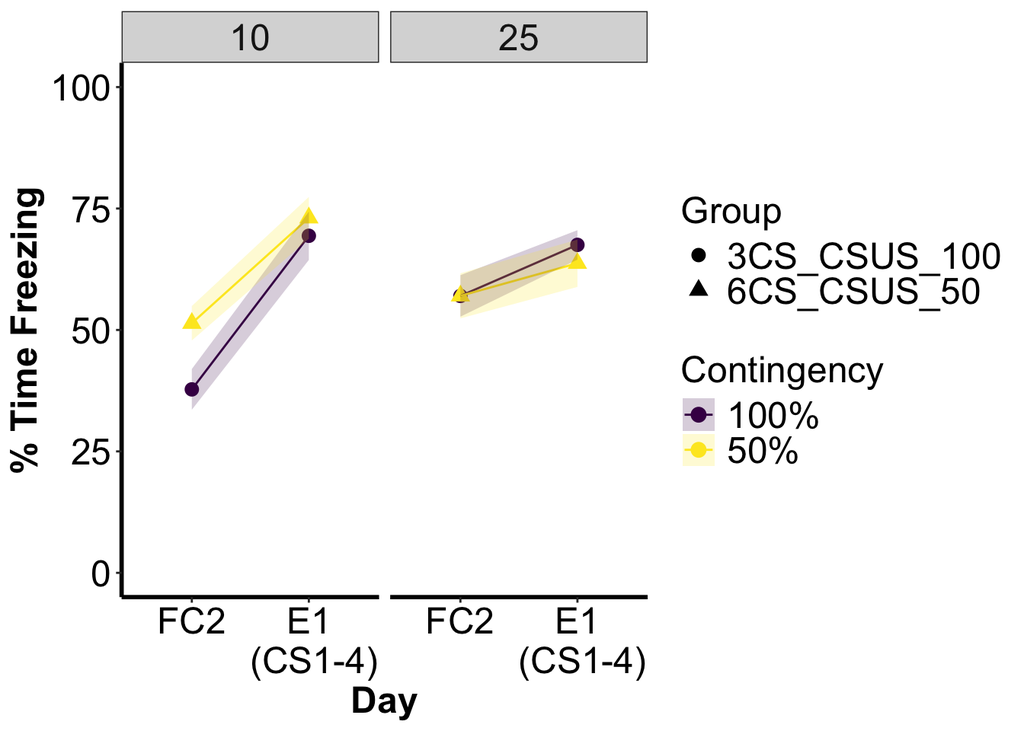

```r
ggplot(
  E1_FC2_ave_1,
  aes(x=Exp_Type,
      y=group_mean_freezing,
      group = Contingency,
      color = Contingency,
      fill = Contingency,
      shape = Group)) +
    scale_fill_viridis(discrete = TRUE) +
  scale_colour_viridis(discrete = TRUE) +
  geom_point(
    size = 3
  ) +
  geom_line(
  ) +
  facet_wrap(
    vars(CS_Time)
  ) +
  ylim(0,100) +
  geom_ribbon(
    aes(
      ymin = group_mean_freezing-se,
      ymax = group_mean_freezing+se),
    alpha = .2,
    color = NA
  ) +
  scale_x_discrete(labels= c("FC2", "E1\n (CS1-4)")) +
  theme_bw() +
  theme(legend.text=element_text(size=18),
        legend.title = element_text(size=18),
        panel.border= element_blank(),
        plot.background = element_blank(),
        plot.title = element_text(size = 18,face="bold.italic", hjust=0.5),
        panel.grid.major = element_blank(),
        panel.grid.minor = element_blank(),
        axis.text.x = element_text(size = 18, color="black"),
        axis.text.y = element_text(size = 18, color="black"),
        axis.title.x = element_text(size = 18, face= "bold"),
        axis.title.y = element_text(size = 18, face="bold"),
        axis.line.x = element_line(color="black", linewidth = 1),
        axis.line.y = element_line(color="black", linewidth = 1),
        strip.text = element_text(size = 18)) +
  labs(
    x = "Day",
    y = "% Time Freezing")
```

### C - Stats

```r
m1c <- E1_FC2_id_1 %>%
  aov_ez(id = "id",
         dv = "mean_freezing",
         between = c("Contingency", "CS_Time"),
         within = "Exp_Type",
         data = .)
```

```
## Converting to factor: Contingency
```

```
## Contrasts set to contr.sum for the following variables: Contingency, CS_Time
```

```r
#ANOVA table
nice_m1c <-nice(m1c)
kable(nice_m1c, caption = '<b>Figure 1C: Main FX</b>') %>%
  kable_styling(bootstrap_options = "striped", full_width = F, position = "left", font_size = 14)
```

**Figure 1C: Main FX**

| Effect | df | MSE | F | ges | p.value |
| --- | --- | --- | --- | --- | --- |
| Contingency | 1, 60 | 302.34 | 1.22 | .010 | .275 |
| CS_Time | 1, 60 | 302.34 | 1.23 | .011 | .271 |
| Contingency:CS_Time | 1, 60 | 302.34 | 2.94 + | .025 | .092 |
| Exp_Type | 1, 60 | 282.17 | 35.27 *** | .221 | <.001 |
| Contingency:Exp_Type | 1, 60 | 282.17 | 1.33 | .011 | .253 |
| CS_Time:Exp_Type | 1, 60 | 282.17 | 9.24 ** | .069 | .004 |
| Contingency:CS_Time:Exp_Type | 1, 60 | 282.17 | 0.26 | .002 | .609 |

```r
n1c_Interaction <- emmeans(m1c, ~ Exp_Type * CS_Time)

#Contrasts for CS Epoch by CS time
E1.10 = c(1,0,0,0)
FC2.10 = c(0,1,0,0)
E1.25 = c(0,0,1,0)
FC2.25 = c(0,0,0,1)

kable(contrast(n1c_Interaction, method = list("Ext(CS1-4)_CS10 - FC2_CS10" = E1.10 - FC2.10,
                                        "Ext(CS1-4)_CS25 - FC2_CS25" = E1.25 - FC2.25),
         adjust = "mvt"), caption = '<b>Figure 1C: Simple Contrast for CS Epoch</b>')
```

**Figure 1C: Simple Contrast for CS Epoch**

| contrast | estimate | SE | df | t.ratio | p.value |
| --- | --- | --- | --- | --- | --- |
| Ext(CS1-4)_CS10 - FC2_CS10 | 26.662552 | 4.199515 | 60 | 6.348961 | 0.0000001 |
| Ext(CS1-4)_CS25 - FC2_CS25 | 8.610104 | 4.199515 | 60 | 2.050262 | 0.0870374 |

## D. Extinction Acquisition——————–

To evaluate the effect of partial reinforcement on fear extinction acquisition, mice were exposed to 12 unreinforced CS presentations for three consecutive days (E1, E2, E3) in a novel context (Context B). Percent time freezing was averaged in bins composed of 3CS presentations.

### D - Dataframe

```r
bin1 =c("tone 01", "tone 02", "tone 03")
bin2 =c("tone 04", "tone 05", "tone 06")
bin3 =c("tone 07", "tone 08", "tone 09")
bin4 =c("tone 10", "tone 11", "tone 12")

EXT_bin_id_1 <- df %>%
  filter(str_detect(Experiment, "E"),
         str_detect(Trials, "3 Trials"),
         str_detect(Experiment, "ER", negate = TRUE)) %>%
  mutate(Bin = ifelse(Component.Name %in% "pre-tone", "Pre",
                      ifelse(Component.Name %in% bin1, "1",
                             ifelse(Component.Name %in% bin2, "2",
                                    ifelse(Component.Name %in% bin3, "3",
                                           ifelse(Component.Name %in% bin4, "4", "Post")))))) %>%
  group_by(Exp_Type, id, Group, CS_Time, Contingency, Bin) %>%
  summarize(mean_freezing=mean(Pct.Component.Time.Freezing), n=n(),
            se=sd(Pct.Component.Time.Freezing/sqrt(n())))
```

```
## 'Contingency'. You can override using the `.groups` argument.
```

```r
EXT_bin_ave_1 <- EXT_bin_id_1 %>%
  group_by(Exp_Type, Bin, Group, CS_Time, Contingency) %>%
  summarize(group_mean_freezing=mean(mean_freezing), n=n(),
            se=sd(mean_freezing/sqrt(n())))
```

```
## can override using the `.groups` argument.
```

```r
EXT_bin_ave_1$Bin <- factor(EXT_bin_ave_1$Bin, levels = c("Pre", "1", "2", "3", "4", "Post"))
```

### D - Graph

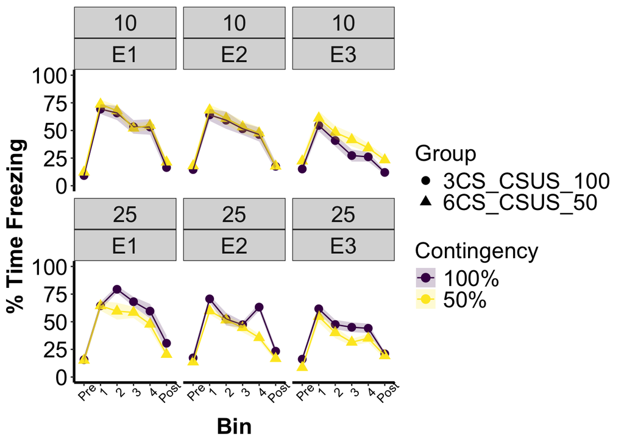

```r
ggplot(
  data = subset(EXT_bin_ave_1, !is.na(Bin)),
  aes(x=Bin,
      y=group_mean_freezing,
      group = Contingency,
      color = Contingency,
      fill = Contingency,
      shape=Group)) +
  scale_fill_viridis(discrete = TRUE) +
  scale_colour_viridis(discrete = TRUE) +
  facet_wrap(
    vars(CS_Time, Exp_Type)
  ) +
  geom_point(
    size = 3
  ) +
  geom_line(
  ) +
  ylim(0,100) +
  geom_ribbon(
    aes(
      ymin = group_mean_freezing-se,
      ymax = group_mean_freezing+se),
    alpha = .2,
    color = NA
  ) +
  theme_bw() +
  theme(legend.text=element_text(size=18),
        legend.title = element_text(size=18),
        panel.border= element_blank(),
        plot.background = element_blank(),
        plot.title = element_text(size = 18,face="bold.italic", hjust=0.5),
        panel.grid.major = element_blank(),
        panel.grid.minor = element_blank(),
        axis.text.x = element_text(size = 10, color="black", angle = 45),
        axis.text.y = element_text(size = 18, color="black"),
        axis.title.x = element_text(size = 18, face= "bold"),
        axis.title.y = element_text(size = 18, face="bold"),
        axis.line.x = element_line(color="black", linewidth = 1),
        axis.line.y = element_line(color="black", linewidth = 1),
        strip.text = element_text(size = 18)) +
  labs(
    x = "Bin",
    y = "% Time Freezing")
```

### D - Stats (ANOVA statistical analyses are represented in figs 1D-E )

```r
###### FE1 ############
m1d.FE <- EXT_bin_id_1 %>%
  filter(str_detect(Bin, "Pre|Post", negate = TRUE)) %>%
  # filter(Exp_Type == "E1") %>%
  aov_ez(id = "id",
         dv = "mean_freezing",
         between = c("Contingency", "CS_Time"),
         within = c("Bin", "Exp_Type"),
         # covariate = "Exp_Type", factorize=FALSE,
         data = .)
```

```
## Converting to factor: Contingency
```

```
## Contrasts set to contr.sum for the following variables: Contingency, CS_Time
```

```r
#ANOVA table
nice_m1d <-nice(m1d.FE)
kable(nice_m1d, caption = '<b>Figure 1D: Main FX</b>') %>%
  kable_styling(bootstrap_options = "striped", full_width = F, position = "left")
```

**Figure 1D: Main FX**

| Effect | df | MSE | F | ges | p.value |
| --- | --- | --- | --- | --- | --- |
| Contingency | 1, 60 | 2415.74 | 0.64 | .005 | .426 |
| CS_Time | 1, 60 | 2415.74 | 0.02 | <.001 | .894 |
| Contingency:CS_Time | 1, 60 | 2415.74 | 4.08 * | .033 | .048 |
| Bin | 2.78, 166.85 | 213.01 | 67.91 *** | .122 | <.001 |
| Contingency:Bin | 2.78, 166.85 | 213.01 | 1.49 | .003 | .221 |
| CS_Time:Bin | 2.78, 166.85 | 213.01 | 2.61 + | .005 | .058 |
| Contingency:CS_Time:Bin | 2.78, 166.85 | 213.01 | 0.87 | .002 | .453 |
| Exp_Type | 1.57, 94.39 | 594.60 | 48.15 *** | .134 | <.001 |
| Contingency:Exp_Type | 1.57, 94.39 | 594.60 | 0.79 | .003 | .431 |
| CS_Time:Exp_Type | 1.57, 94.39 | 594.60 | 1.54 | .005 | .221 |
| Contingency:CS_Time:Exp_Type | 1.57, 94.39 | 594.60 | 0.40 | .001 | .620 |
| Bin:Exp_Type | 4.99, 299.10 | 181.22 | 4.41 *** | .014 | <.001 |
| Contingency:Bin:Exp_Type | 4.99, 299.10 | 181.22 | 2.22 + | .007 | .052 |
| CS_Time:Bin:Exp_Type | 4.99, 299.10 | 181.22 | 3.49 ** | .011 | .004 |
| Contingency:CS_Time:Bin:Exp_Type | 4.99, 299.10 | 181.22 | 2.72 * | .008 | .020 |

```r
n1d <- emmeans(m1d.FE, ~ Contingency* Exp_Type * CS_Time * Bin)

#Simple contrasts for Contingency
n1d_pairs <- pairs(n1d, simple="Contingency")
kable(n1d_pairs, caption = '<b>Figure 1D: Significant Simple Contrasts for Contingency</b>')
```

**Figure 1D: Significant Simple Contrasts for Contingency**

| contrast | Exp_Type | CS_Time | Bin | estimate | SE | df | t.ratio | p.value |
| --- | --- | --- | --- | --- | --- | --- | --- | --- |
| 100% - 50% | E1 | 10 | X1 | -4.3775000 | 5.814720 | 60 | -0.7528307 | 0.4544954 |
| 100% - 50% | E2 | 10 | X1 | -4.3564583 | 6.125448 | 60 | -0.7112064 | 0.4797122 |
| 100% - 50% | E3 | 10 | X1 | -6.5193750 | 7.524159 | 60 | -0.8664590 | 0.3896903 |
| 100% - 50% | E1 | 25 | X1 | 0.0475000 | 5.814720 | 60 | 0.0081689 | 0.9935093 |
| 100% - 50% | E2 | 25 | X1 | 10.8387500 | 6.125448 | 60 | 1.7694623 | 0.0818984 |
| 100% - 50% | E3 | 25 | X1 | 6.9639583 | 7.524159 | 60 | 0.9255464 | 0.3583896 |
| 100% - 50% | E1 | 10 | X2 | -1.9483333 | 8.121100 | 60 | -0.2399100 | 0.8112177 |
| 100% - 50% | E2 | 10 | X2 | -1.5779167 | 8.470527 | 60 | -0.1862832 | 0.8528511 |
| 100% - 50% | E3 | 10 | X2 | -7.3716667 | 7.244326 | 60 | -1.0175781 | 0.3129643 |
| 100% - 50% | E1 | 25 | X2 | 19.7831250 | 8.121100 | 60 | 2.4360156 | 0.0178364 |
| 100% - 50% | E2 | 25 | X2 | 0.8477083 | 8.470527 | 60 | 0.1000774 | 0.9206165 |
| 100% - 50% | E3 | 25 | X2 | 7.3672917 | 7.244326 | 60 | 1.0169741 | 0.3132491 |
| 100% - 50% | E1 | 10 | X3 | 1.1497917 | 7.088220 | 60 | 0.1622116 | 0.8716843 |
| 100% - 50% | E2 | 10 | X3 | -1.6916667 | 6.699328 | 60 | -0.2525129 | 0.8015077 |
| 100% - 50% | E3 | 10 | X3 | -14.2914583 | 6.894027 | 60 | -2.0730202 | 0.0424732 |
| 100% - 50% | E1 | 25 | X3 | 9.6585417 | 7.088220 | 60 | 1.3626188 | 0.1780955 |
| 100% - 50% | E2 | 25 | X3 | 2.6218750 | 6.699328 | 60 | 0.3913639 | 0.6969147 |
| 100% - 50% | E3 | 25 | X3 | 13.5775000 | 6.894027 | 60 | 1.9694583 | 0.0535228 |
| 100% - 50% | E1 | 10 | X4 | -1.4668750 | 8.153658 | 60 | -0.1799039 | 0.8578342 |
| 100% - 50% | E2 | 10 | X4 | -1.3610417 | 6.640532 | 60 | -0.2049597 | 0.8382973 |
| 100% - 50% | E3 | 10 | X4 | -8.0520833 | 5.873583 | 60 | -1.3708980 | 0.1755132 |
| 100% - 50% | E1 | 25 | X4 | 11.8187500 | 8.153658 | 60 | 1.4495027 | 0.1524042 |
| 100% - 50% | E2 | 25 | X4 | 27.6160417 | 6.640532 | 60 | 4.1587095 | 0.0001034 |
| 100% - 50% | E3 | 25 | X4 | 8.9489583 | 5.873583 | 60 | 1.5235944 | 0.1328638 |

## E. Extinction Consolidation——————–

We investigated whether partial reinforcement could affect 24-hr consolidation of extinction learning across the three extinction sessions. For this analysis we averaged percent time freezing across all CS presentations per extinction training day.

### E - Dataframe

```r
EXT_id_1 <- df %>%
  filter(str_detect(Component.Name, "pre-tone|post-tone", negate = TRUE),
         str_detect(Trials, "3 Trials"),
         str_detect(Exp_Type, "E"),
         str_detect(Exp_Type, "ER", negate = TRUE)) %>%
  group_by(Exp_Type, id, Group, CS_Time, Contingency) %>%
  summarize(mean_freezing=mean(Pct.Component.Time.Freezing), n=n(),
            se=sd(Pct.Component.Time.Freezing/sqrt(n())))
```

```
## can override using the `.groups` argument.
```

```r
EXT_ave_1 <- EXT_id_1 %>%
  group_by(Exp_Type, CS_Time, Group, Contingency) %>%
  summarize(group_mean_freezing=mean(mean_freezing), n=n(),
            se=sd(mean_freezing/sqrt(n())))
```

### E - Graph

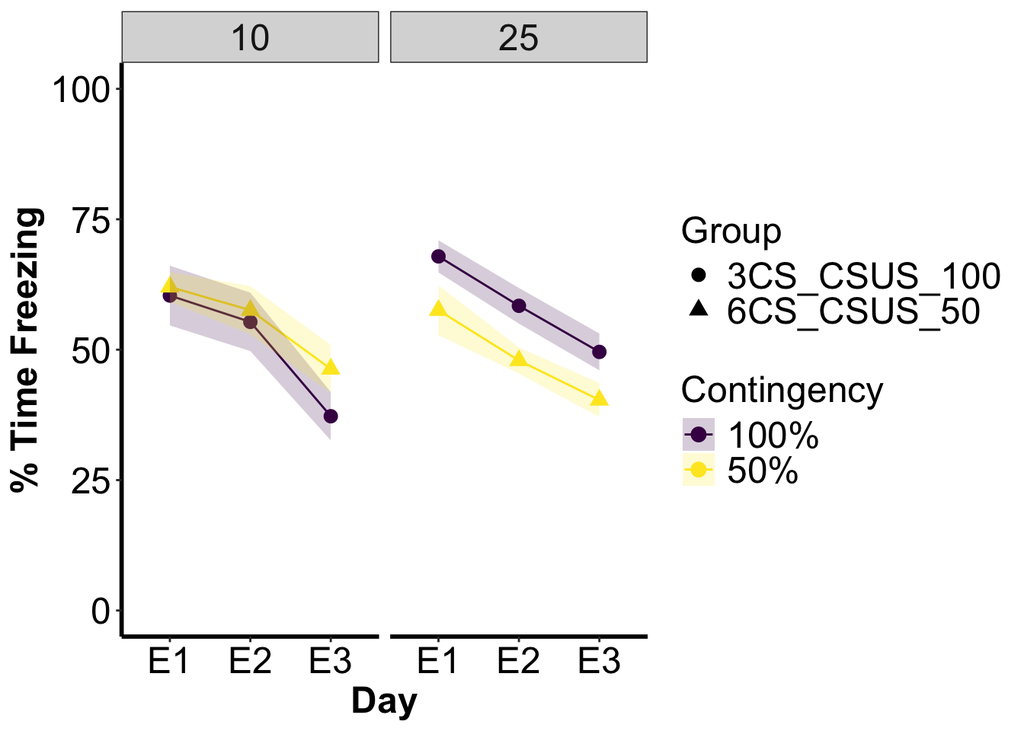

```r
ggplot(
  EXT_ave_1,
  aes(x=Exp_Type,
      y=group_mean_freezing,
      group = Contingency,
      color = Contingency,
      fill = Contingency,
      shape = Group)) +
  scale_fill_viridis(discrete = TRUE) +
  scale_colour_viridis(discrete = TRUE) +
  geom_point(
    size = 3
  ) +
  geom_line(
  ) +
  facet_wrap(
    vars(CS_Time)
  ) +
  ylim(0,100) +
  geom_ribbon(
    aes(
      ymin = group_mean_freezing-se,
      ymax = group_mean_freezing+se),
    alpha = .2,
    color = NA
  ) +
  theme_bw() +
  theme(legend.text=element_text(size=18),
        legend.title = element_text(size=18),
        panel.border= element_blank(),
        plot.background = element_blank(),
        plot.title = element_text(size = 18,face="bold.italic", hjust=0.5),
        panel.grid.major = element_blank(),
        panel.grid.minor = element_blank(),
        axis.text.x = element_text(size = 18, color="black"),
        axis.text.y = element_text(size = 18, color="black"),
        axis.title.x = element_text(size = 18, face= "bold"),
        axis.title.y = element_text(size = 18, face="bold"),
        axis.line.x = element_line(color="black", linewidth = 1),
        axis.line.y = element_line(color="black", linewidth = 1),
        strip.text = element_text(size = 18)) +
  labs(
    x = "Day",
    y = "% Time Freezing")
```

### E - Stats

```r
n1e <- emmeans(m1d.FE, ~ Contingency* Exp_Type * CS_Time)
n1e_pairs <- pairs(n1e, simple=c("Exp_Type"))

#Simple contrasts for Exp_Type
kable(n1e_pairs, caption = '<b>Figure 1E: Simple Contrast for Extinction Session (i.e. "Exp_Type")</b>')
```

**Figure 1E: Simple Contrast for Extinction Session (i.e. “Exp_Type”)**

| contrast | Contingency | CS_Time | estimate | SE | df | t.ratio | p.value |
| --- | --- | --- | --- | --- | --- | --- | --- |
| E1 - E2 | 100% | 10 | 5.050208 | 4.412635 | 60 | 1.144488 | 0.4908246 |
| E1 - E3 | 100% | 10 | 23.133698 | 4.155200 | 60 | 5.567409 | 0.0000019 |
| E2 - E3 | 100% | 10 | 18.083490 | 2.666354 | 60 | 6.782104 | 0.0000000 |
| E1 - E2 | 50% | 10 | 4.464167 | 4.412635 | 60 | 1.011678 | 0.5724437 |
| E1 - E3 | 50% | 10 | 15.735781 | 4.155200 | 60 | 3.787009 | 0.0010219 |
| E2 - E3 | 50% | 10 | 11.271615 | 2.666354 | 60 | 4.227351 | 0.0002388 |
| E1 - E2 | 100% | 25 | 9.470885 | 4.412635 | 60 | 2.146310 | 0.0891451 |
| E1 - E3 | 100% | 25 | 18.311198 | 4.155200 | 60 | 4.406815 | 0.0001291 |
| E2 - E3 | 100% | 25 | 8.840312 | 2.666354 | 60 | 3.315506 | 0.0043762 |
| E1 - E2 | 50% | 25 | 9.625000 | 4.412635 | 60 | 2.181236 | 0.0826615 |
| E1 - E3 | 50% | 25 | 17.198646 | 4.155200 | 60 | 4.139066 | 0.0003217 |
| E2 - E3 | 50% | 25 | 7.573646 | 2.666354 | 60 | 2.840450 | 0.0166739 |

## F. Extinction Recall——————–

Extinction recall was measured at recent (48 h) or remote (30 d) timepoints. Mice were returned to Context B and received a tone test (4 CS presentations) 48 hours and 30 days after the last day of extinction training. In addition to comparing experimental groups at each time point, we also compared percent time freezing within-subjects between the recent and remote time points to assess the level of spontaneous recovery, or the return of conditioned fear with the passage of time

### F - Dataframe

```r
ER_id_1 <- df %>%
  filter(str_detect(Component.Name, "pre-tone|post-tone", negate = TRUE),
         str_detect(Trials, "3 Trials"),
         str_detect(Exp_Type, "ER")) %>%
  group_by(id, Group, CS_Time, Contingency, Exp_Type) %>%
  summarize(mean_freezing=mean(Pct.Component.Time.Freezing), n=n(),
            se=sd(Pct.Component.Time.Freezing/sqrt(n())))
```

```
## You can override using the `.groups` argument.
```

```r
ER_ave_1 <- ER_id_1 %>%
  group_by(CS_Time, Group, Contingency, Exp_Type) %>%
  summarize(group_mean_freezing=mean(mean_freezing), n=n(),
            se=sd(mean_freezing/sqrt(n())))
SR_id_1 <- df %>%
  filter(str_detect(Component.Name, "pre-tone|post-tone", negate = TRUE),
         str_detect(Trials, "3 Trials"),
         str_detect(Exp_Type, "SR")) %>%
  group_by(id, Group, CS_Time, Contingency, Exp_Type, Sex) %>%
  summarize(mean_freezing=mean(Pct.Component.Time.Freezing), n=n(),
            se=sd(Pct.Component.Time.Freezing/sqrt(n())))
```

```
## 'Exp_Type'. You can override using the `.groups` argument.
```

```r
SR_ave_1 <- SR_id_1 %>%
  group_by(CS_Time, Group, Contingency, Exp_Type) %>%
  summarize(group_mean_freezing=mean(mean_freezing), n=n(),
            se=sd(mean_freezing/sqrt(n())))
ER_SR_id_1 <-rbind(ER_id_1, SR_id_1)
ER_SR_ave_1 <-rbind(ER_ave_1, SR_ave_1)
```

### F - Graph

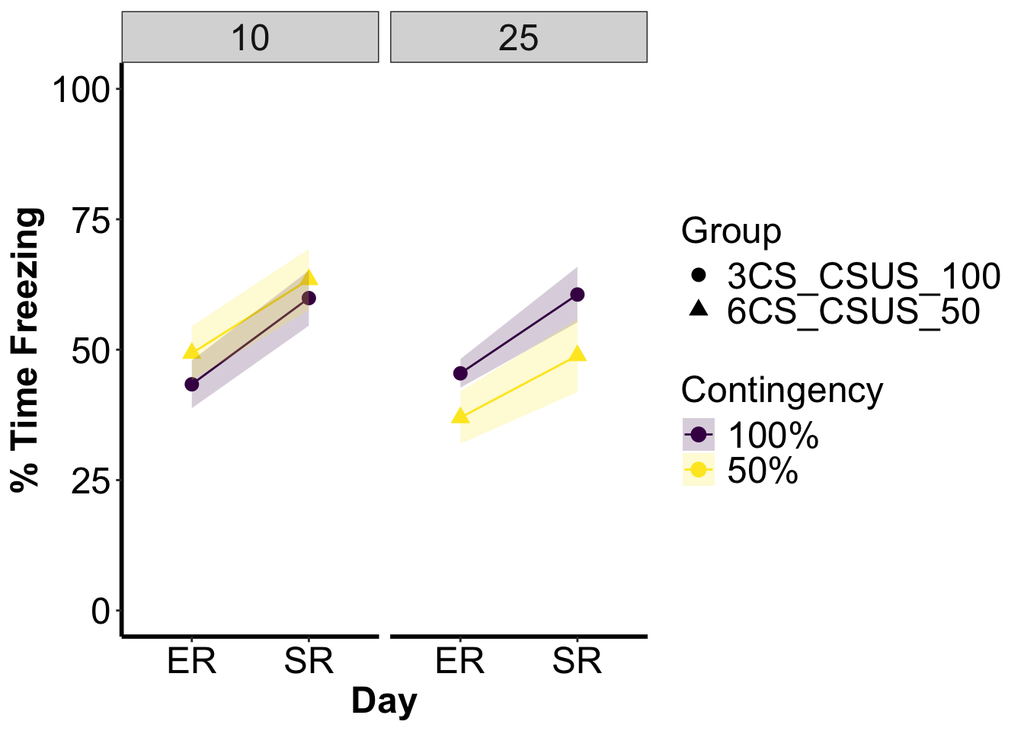

```r
ggplot(
  ER_SR_ave_1,
  aes(x=Exp_Type,
      y=group_mean_freezing,
      group = Contingency,
      color = Contingency,
      fill = Contingency,
      shape = Group)) +
  scale_fill_viridis(discrete = TRUE) +
  scale_colour_viridis(discrete = TRUE) +
  geom_point(
    size = 3
  ) +
  geom_line(
  ) +
  facet_wrap(
    vars(CS_Time)
  ) +
  ylim(0,100) +
  geom_ribbon(
    aes(
      ymin = group_mean_freezing-se,
      ymax = group_mean_freezing+se),
    alpha = .2,
    color = NA
  ) +
  theme_bw() +
  theme(legend.text=element_text(size=18),
        legend.title = element_text(size=18),
        panel.border= element_blank(),
        plot.background = element_blank(),
        plot.title = element_text(size = 18,face="bold.italic", hjust=0.5),
        panel.grid.major = element_blank(),
        panel.grid.minor = element_blank(),
        axis.text.x = element_text(size = 18, color="black"),
        axis.text.y = element_text(size = 18, color="black"),
        axis.title.x = element_text(size = 18, face= "bold"),
        axis.title.y = element_text(size = 18, face="bold"),
        axis.line.x = element_line(color="black", linewidth = 1),
        axis.line.y = element_line(color="black", linewidth = 1),
        strip.text = element_text(size = 18)) +
  labs(
    x = "Day",
    y = "% Time Freezing")
```

### F - Stats

```r
m1f <- ER_SR_id_1 %>%
  aov_ez(id = "id",
         dv = "mean_freezing",
         between = c("Contingency", "CS_Time"),
         within = "Exp_Type",
         data = .)
```

```
## Converting to factor: Contingency
```

```
## Contrasts set to contr.sum for the following variables: Contingency, CS_Time
```

```r
nice_m1f <- nice(m1f)

kable(nice_m1f, caption = '<b>Figure 1F</b>') %>%
  kable_styling(bootstrap_options = "striped", full_width = F, position = "left")
```

**Figure 1F**

| Effect | df | MSE | F | ges | p.value |
| --- | --- | --- | --- | --- | --- |
| Contingency | 1, 56 | 451.34 | 0.98 | .010 | .326 |
| CS_Time | 1, 56 | 451.34 | 3.43 + | .034 | .069 |
| Contingency:CS_Time | 1, 56 | 451.34 | 4.88 * | .047 | .031 |
| Exp_Type | 1, 56 | 343.57 | 20.99 *** | .139 | <.001 |
| Contingency:Exp_Type | 1, 56 | 343.57 | 0.00 | <.001 | .956 |
| CS_Time:Exp_Type | 1, 56 | 343.57 | 0.01 | <.001 | .931 |
| Contingency:CS_Time:Exp_Type | 1, 56 | 343.57 | 0.09 | <.001 | .770 |

```r
n1f <- emmeans(m1f, ~Exp_Type * Contingency * CS_Time)

n1f_ExpType <- pairs(n1f, simple = "Exp_Type")
n1f_Interaction <- pairs(n1f, simple = c("Contingency", "CS_Time"))

#Simple contrasts for ExpType
kable(n1f_ExpType, caption = '<b>Figure 1F: Simple Contrast for Exp_Type')
```

**Figure 1F: Simple Contrast for Exp_Type**

| contrast | Contingency | CS_Time | estimate | SE | df | t.ratio | p.value |
| --- | --- | --- | --- | --- | --- | --- | --- |
| ER - SR | 100% | 10 | -16.52219 | 6.553361 | 56 | -2.521178 | 0.0145700 |
| ER - SR | 50% | 10 | -14.13297 | 6.553361 | 56 | -2.156598 | 0.0353455 |
| ER - SR | 100% | 25 | -15.10922 | 6.553361 | 56 | -2.305568 | 0.0248620 |
| ER - SR | 50% | 25 | -16.73396 | 7.567170 | 56 | -2.211389 | 0.0311077 |

```r
#Simple contrasts for Contingency x CS_Time interaction
kable(n1f_Interaction, caption = '<b>Figure 1F: Simple Contrast for Contingency x CS_Time ')
```

**Figure 1F: Simple Contrast for Contingency x CS_Time**

| contrast | Exp_Type | estimate | SE | df | t.ratio | p.value |
| --- | --- | --- | --- | --- | --- | --- |
| 100% CS_Time10 - 50% CS_Time10 | ER | -5.9600000 | 6.029732 | 56 | -0.9884353 | 0.7565835 |
| 100% CS_Time10 - 100% CS_Time25 | ER | -2.1000000 | 6.029732 | 56 | -0.3482742 | 0.9853401 |
| 100% CS_Time10 - 50% CS_Time25 | ER | 11.2211979 | 6.512855 | 56 | 1.7229307 | 0.3216608 |
| 50% CS_Time10 - 100% CS_Time25 | ER | 3.8600000 | 6.029732 | 56 | 0.6401611 | 0.9185206 |
| 50% CS_Time10 - 50% CS_Time25 | ER | 17.1811979 | 6.512855 | 56 | 2.6380439 | 0.0512007 |
| 100% CS_Time25 - 50% CS_Time25 | ER | 13.3211979 | 6.512855 | 56 | 2.0453699 | 0.1839867 |
| 100% CS_Time10 - 50% CS_Time10 | SR | -3.5707813 | 7.937677 | 56 | -0.4498522 | 0.9693879 |
| 100% CS_Time10 - 100% CS_Time25 | SR | -0.6870313 | 7.937677 | 56 | -0.0865532 | 0.9997647 |
| 100% CS_Time10 - 50% CS_Time25 | SR | 11.0094271 | 8.573671 | 56 | 1.2840972 | 0.5767637 |
| 50% CS_Time10 - 100% CS_Time25 | SR | 2.8837500 | 7.937677 | 56 | 0.3632990 | 0.9834290 |
| 50% CS_Time10 - 50% CS_Time25 | SR | 14.5802083 | 8.573671 | 56 | 1.7005794 | 0.3330483 |
| 100% CS_Time25 - 50% CS_Time25 | SR | 11.6964583 | 8.573671 | 56 | 1.3642299 | 0.5267494 |

# Fig 2. No effect of partial reinforcement on fear extinction acquisition or consolidation with increased CS:US trials during fear conditioning:

Since we did not observe a PREE in experiments shown in Fig 1, we tested whether an increased number of CS:US trials was necessary to reveal extinction resistance using partial reinforcement (Brimer and Dockrill, 1966). To do this, we repeated the experiments (as in Fig. 1A) but doubled the number of CS:US trials (12:6 CS:US pairs for 50% contingency; 6:6 CS:US pairs for 100% contingency, Fig. 2A). Given that CS duration did not significantly alter fear extinction in prior experiments (see Fig. 1E and F), we used only one CS duration (10 sec) for all trials.

## B. Fear Acquisition——————–

Compare the average percent time freezing during CS presentations across the two days of FC training

### B - Tidy dataframe

```r
FC_id_2 <- df %>%
  filter(str_detect(Component.Name, "pre-tone|post-tone", negate = TRUE),
         str_detect(Exp_Type, "FC"),
         str_detect(CS_Time, "10"),
         str_detect(Trials, "6 Trials")) %>%
  group_by(id, Group, Contingency, CS_Time, Trials) %>%
  summarize(mean_freezing=mean(Pct.Component.Time.Freezing), n=n(),
            se=sd(Pct.Component.Time.Freezing/sqrt(n())))
```

```
## You can override using the `.groups` argument.
```

```r
FC_ave_2 <- FC_id_2 %>%
  group_by(Group, Contingency, CS_Time, Trials) %>%
  summarize(group_mean_freezing=mean(mean_freezing), n=n(),
            se=sd(mean_freezing/sqrt(n())))
```

### B - Graph

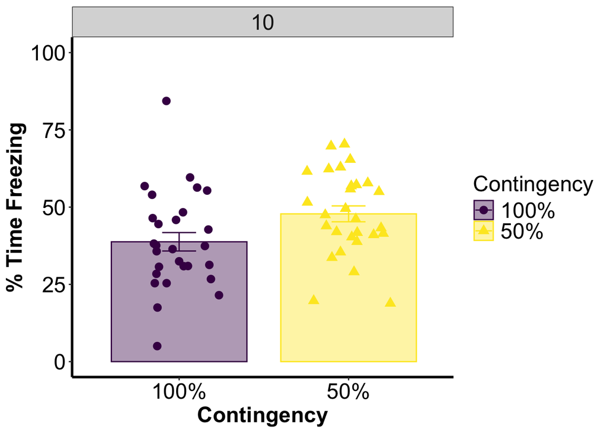

```r
ggplot(FC_ave_2,
       aes(x=Contingency,
           y=group_mean_freezing,
           group=Contingency,
           color=Contingency,
           fill=Contingency,
           shape=Contingency)) +
  scale_fill_viridis(discrete = TRUE) +
  scale_colour_viridis(discrete = TRUE) +
  geom_bar(
    stat = "identity",
    position = "dodge",
    width=0.8,
    alpha=0.4) +
  geom_errorbar(
    aes(
      ymin = group_mean_freezing-se,
      ymax = group_mean_freezing+se,
      width = .2),
    position=position_dodge(width=0.8)
  ) +
  geom_point(
    data=FC_id_2,
    aes(x=Contingency, y=mean_freezing),
    position = position_jitterdodge(jitter.height=0, jitter.width=0.5,
                                    dodge.width = 0.8),
    size=3
  ) +
  facet_wrap(
    vars(CS_Time)) +
  ylim(0,100) +
  theme_bw() +
  theme(legend.text=element_text(size=18),
        legend.title = element_text(size=18),
        panel.border= element_blank(),
        plot.background = element_blank(),
        plot.title = element_text(size = 18,face="bold.italic", hjust=0.5),
        panel.grid.major = element_blank(),
        panel.grid.minor = element_blank(),
        axis.text.x = element_text(size = 18, color="black"),
        axis.text.y = element_text(size = 18, color="black"),
        axis.title.x = element_text(size = 18, face= "bold"),
        axis.title.y = element_text(size = 18, face="bold"),
        axis.line.x = element_line(color="black", linewidth = 1),
        axis.line.y = element_line(color="black", linewidth = 1),
        strip.text = element_text(size = 18)) +
  labs(
    x = "Contingency",
    y = "% Time Freezing")
```

### B - Stats

```r
m2b <- FC_id_2 %>%
  aov_ez(id = "id",
         dv = "mean_freezing",
         between = "Contingency",
         data = .)
```

```
## Converting to factor: Contingency
```

```
## Contrasts set to contr.sum for the following variables: Contingency
```

```r
nice_m2b <- nice(m2b)

kable(nice_m2b, caption = '<b>Figure 2B: Main FX</b>') %>%
  kable_styling(bootstrap_options = "striped", full_width = F, position = "left")
```

**Figure 2B: Main FX**

| Effect | df | MSE | F | ges | p.value |
| --- | --- | --- | --- | --- | --- |
| Contingency | 1, 54 | 216.72 | 5.28 * | .089 | .026 |

## C. Fear Retrieval——————–

Retrieval was evaluated as the proportion of time freezing between two CS epochs: (1) CS freezing on FC Day 2 and (2) the first four CS presentations on Extinction Day 1.

### C - Tidy

```r
E1_Session1_id_2 <- df %>%
  filter(str_detect(Experiment, "E1"),
         str_detect(Experiment, "ER", negate = TRUE),
         str_detect(CS_Time, "10"),
         str_detect(Trials, "6 Trials"),
         str_detect(Component.Name,  "tone 01|tone 02|tone 03|tone 04")) %>%
  group_by(id, Group, CS_Time, Contingency, Exp_Type) %>%
  summarize(mean_freezing=mean(Pct.Component.Time.Freezing), n=n(),
            se=sd(Pct.Component.Time.Freezing/sqrt(n())))
```

```
## You can override using the `.groups` argument.
```

```r
E1_Session1_ave_2 <- E1_Session1_id_2 %>%
  group_by(CS_Time, Group, Contingency, Exp_Type) %>%
  summarize(group_mean_freezing=mean(mean_freezing), n=n(),
            se=sd(mean_freezing/sqrt(n())))
FC2_id_2 <- df %>%
  filter(str_detect(Component.Name, "pre-tone|post-tone", negate = TRUE),
         str_detect(Exp_Type, "FC2"),
         str_detect(CS_Time, "10"),
         str_detect(Trials, "6 Trials")) %>%
  group_by(id, Group, CS_Time, Contingency, Exp_Type) %>%
  summarize(mean_freezing=mean(Pct.Component.Time.Freezing), n=n(),
            se=sd(Pct.Component.Time.Freezing/sqrt(n())))
```

```
## You can override using the `.groups` argument.
```

```r
FC2_ave_2 <- FC2_id_2 %>%
  group_by(CS_Time, Group, Contingency, Exp_Type) %>%
  summarize(group_mean_freezing=mean(mean_freezing), n=n(),
            se=sd(mean_freezing/sqrt(n())))
E1_FC2_ave_2 <-rbind(E1_Session1_ave_2, FC2_ave_2)
E1_FC2_ave_2 <- E1_FC2_ave_2 %>%
  mutate(Exp_Type = if_else(Exp_Type == "E1", "Session 1", Exp_Type))

E1_FC2_id_2 <-rbind(E1_Session1_id_2, FC2_id_2)
E1_FC2_id_2 <- E1_FC2_id_2 %>%
  mutate(Exp_Type = if_else(Exp_Type == "E1", "Session 1", Exp_Type))
```

### C - Graph

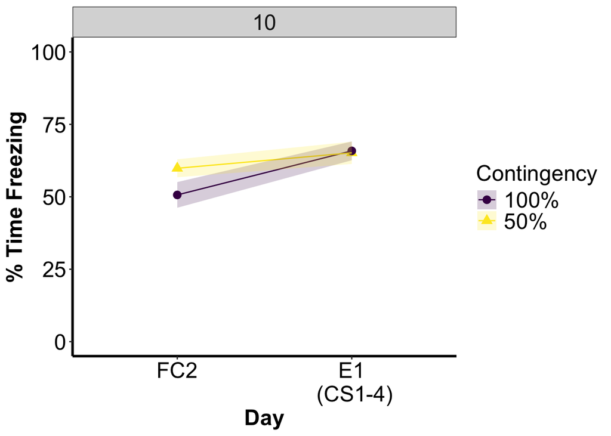

```r
ggplot(
  E1_FC2_ave_2,
  aes(x=Exp_Type,
      y=group_mean_freezing,
      group = Contingency,
      color = Contingency,
      fill = Contingency,
      shape = Contingency)) +
  scale_fill_viridis(discrete = TRUE) +
  scale_colour_viridis(discrete = TRUE) +
  geom_point(
    size = 3
  ) +
  geom_line(
  ) +
  facet_wrap(
    vars(CS_Time)
  ) +
  ylim(0,100) +
  geom_ribbon(
    aes(
      ymin = group_mean_freezing-se,
      ymax = group_mean_freezing+se),
    alpha = .2,
    color = NA
  ) +
  scale_x_discrete(labels= c("FC2", "E1\n (CS1-4)")) +
  theme_bw() +
  theme(legend.text=element_text(size=18),
        legend.title = element_text(size=18),
        panel.border= element_blank(),
        plot.background = element_blank(),
        plot.title = element_text(size = 18,face="bold.italic", hjust=0.5),
        panel.grid.major = element_blank(),
        panel.grid.minor = element_blank(),
        axis.text.x = element_text(size = 18, color="black"),
        axis.text.y = element_text(size = 18, color="black"),
        axis.title.x = element_text(size = 18, face= "bold"),
        axis.title.y = element_text(size = 18, face="bold"),
        axis.line.x = element_line(color="black", linewidth = 1),
        axis.line.y = element_line(color="black", linewidth = 1),
        strip.text = element_text(size = 18)) +
  labs(
    x = "Day",
    y = "% Time Freezing")
```

### C - Stats

```r
m2c <- E1_FC2_id_2 %>%
  aov_ez(id = "id",
         dv = "mean_freezing",
         between = "Contingency",
         within = "Exp_Type",
         data = .)
```

```
## Converting to factor: Contingency
```

```
## Contrasts set to contr.sum for the following variables: Contingency
```

```r
nice_m2c <- nice(m2c)

kable(nice_m2c, caption = '<b>Figure 2C: Main FX</b>') %>%
  kable_styling(bootstrap_options = "striped", full_width = F, position = "left")
```

**Figure 2C: Main FX**

| Effect | df | MSE | F | ges | p.value |
| --- | --- | --- | --- | --- | --- |
| Contingency | 1, 50 | 400.00 | 0.85 | .009 | .360 |
| Exp_Type | 1, 50 | 313.82 | 7.66 ** | .063 | .008 |
| Contingency:Exp_Type | 1, 50 | 313.82 | 1.53 | .013 | .222 |

## D. Extinction Acquisition——————–

To evaluate the effect of partial reinforcement on fear extinction acquisition, mice were exposed to 12 unreinforced CS presentations for three consecutive days (E1, E2, E3) in a novel context (Context B). Percent time freezing was averaged in bins composed of 3CS presentations.

### D - Tidy

```r
bin1 =c("tone 01", "tone 02", "tone 03")
bin2 =c("tone 04", "tone 05", "tone 06")
bin3 =c("tone 07", "tone 08", "tone 09")
bin4 =c("tone 10", "tone 11", "tone 12")

EXT_bin_id_2 <- df %>%
  filter(str_detect(Experiment, "E"),
         str_detect(CS_Time, "10"),
         str_detect(Trials, "6 Trials"),
         str_detect(Experiment, "ER", negate = TRUE)) %>%
  mutate(Bin = ifelse(Component.Name %in% "pre-tone", "Pre",
                      ifelse(Component.Name %in% bin1, "1",
                             ifelse(Component.Name %in% bin2, "2",
                                    ifelse(Component.Name %in% bin3, "3",
                                           ifelse(Component.Name %in% bin4, "4", "Post")))))) %>%
  group_by(Exp_Type, id, Group, CS_Time, Contingency, Bin) %>%
  summarize(mean_freezing=mean(Pct.Component.Time.Freezing), n=n(),
            se=sd(Pct.Component.Time.Freezing/sqrt(n())))
```

```
## 'Contingency'. You can override using the `.groups` argument.
```

```r
EXT_bin_ave_2 <- EXT_bin_id_2 %>%
  group_by(Exp_Type, Bin, Group, CS_Time, Contingency) %>%
  summarize(group_mean_freezing=mean(mean_freezing), n=n(),
            se=sd(mean_freezing/sqrt(n())))
```

```
## can override using the `.groups` argument.
```

```r
EXT_bin_ave_2$Bin <- factor(EXT_bin_ave_2$Bin, levels = c("Pre", "1", "2", "3", "4", "Post"))
```

### D - Graph

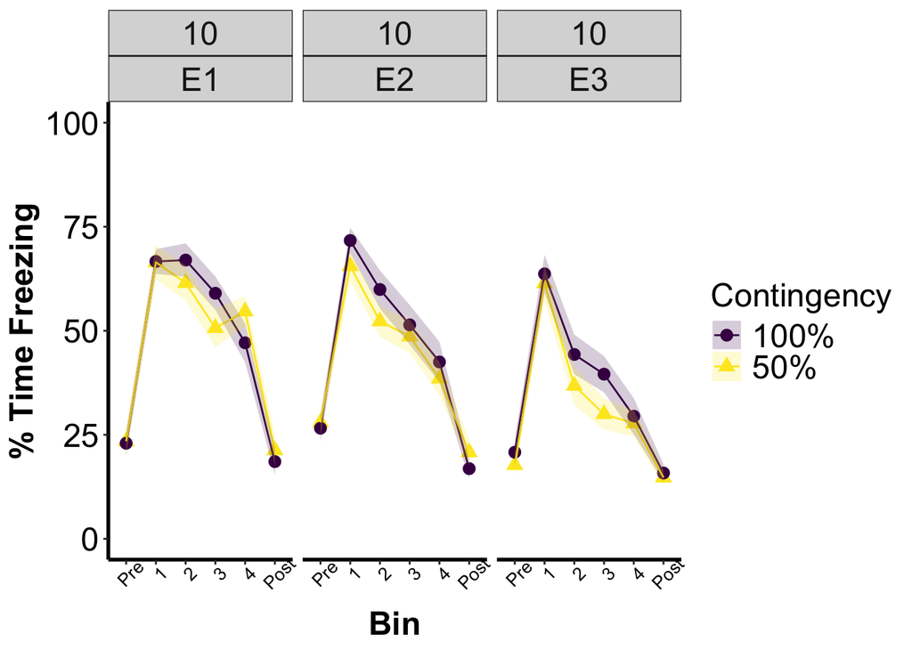

```r
ggplot(
  data = subset(EXT_bin_ave_2, !is.na(Bin)),
  aes(x=Bin,
      y=group_mean_freezing,
      group = Contingency,
      color = Contingency,
      fill = Contingency,
      shape=Contingency)) +
    scale_fill_viridis(discrete = TRUE) +
  scale_colour_viridis(discrete = TRUE) +
  facet_wrap(
    vars(CS_Time, Exp_Type)
  ) +
  geom_point(
    size = 3
  ) +
  geom_line(
  ) +
  ylim(0,100) +
  geom_ribbon(
    aes(
      ymin = group_mean_freezing-se,
      ymax = group_mean_freezing+se),
    alpha = .2,
    color = NA
  ) +
  theme_bw() +
  theme(legend.text=element_text(size=18),
        legend.title = element_text(size=18),
        panel.border= element_blank(),
        plot.background = element_blank(),
        plot.title = element_text(size = 18,face="bold.italic", hjust=0.5),
        panel.grid.major = element_blank(),
        panel.grid.minor = element_blank(),
        axis.text.x = element_text(size = 10, color="black", angle = 45),
        axis.text.y = element_text(size = 18, color="black"),
        axis.title.x = element_text(size = 18, face= "bold"),
        axis.title.y = element_text(size = 18, face="bold"),
        axis.line.x = element_line(color="black", linewidth = 1),
        axis.line.y = element_line(color="black", linewidth = 1),
        strip.text = element_text(size = 18)) +
  labs(
    x = "Bin",
    y = "% Time Freezing")
```

### D - Stats

```r
m2d <- EXT_bin_id_2 %>%
  filter(str_detect(Bin, "Pre|Post", negate = TRUE)) %>%
  aov_ez(id = "id",
         dv = "mean_freezing",
         between = "Contingency",
         within = c("Exp_Type", "Bin"),
         data = .)
```

```
## Converting to factor: Contingency
```

```
## Contrasts set to contr.sum for the following variables: Contingency
```

```r
m2d
```

```
## Anova Table (Type 3 tests)
##
## Response: mean_freezing
##                     Effect           df     MSE         F   ges p.value
## 1              Contingency        1, 50 2660.49      1.10  .010    .299
## 2                 Exp_Type  1.76, 88.13  897.21 22.48 ***  .110   <.001
## 3     Contingency:Exp_Type  1.76, 88.13  897.21      0.12 <.001    .864
## 4                      Bin 2.60, 130.07  222.52 98.28 ***  .165   <.001
## 5          Contingency:Bin 2.60, 130.07  222.52    3.10 *  .006    .036
## 6             Exp_Type:Bin 5.18, 258.93  182.95  6.95 ***  .022   <.001
## 7 Contingency:Exp_Type:Bin 5.18, 258.93  182.95      1.36  .004    .238
## ---
## Signif. codes:  0 '***' 0.001 '**' 0.01 '*' 0.05 '+' 0.1 ' ' 1
##
## Sphericity correction method: GG
```

```r
nice_m2d <- nice(m2d)

kable(nice_m2d, caption = '<b>Figure 2D</b>') %>%
  kable_styling(bootstrap_options = "striped", full_width = F, position = "left")
```

**Figure 2D**

| Effect | df | MSE | F | ges | p.value |
| --- | --- | --- | --- | --- | --- |
| Contingency | 1, 50 | 2660.49 | 1.10 | .010 | .299 |
| Exp_Type | 1.76, 88.13 | 897.21 | 22.48 *** | .110 | <.001 |
| Contingency:Exp_Type | 1.76, 88.13 | 897.21 | 0.12 | <.001 | .864 |
| Bin | 2.60, 130.07 | 222.52 | 98.28 *** | .165 | <.001 |
| Contingency:Bin | 2.60, 130.07 | 222.52 | 3.10 * | .006 | .036 |
| Exp_Type:Bin | 5.18, 258.93 | 182.95 | 6.95 *** | .022 | <.001 |
| Contingency:Exp_Type:Bin | 5.18, 258.93 | 182.95 | 1.36 | .004 | .238 |

```r
n2d <- emmeans(m2d, ~ Contingency* Exp_Type * Bin)

#Simple contrasts for Contingency X Bin: Contrast reported but not of interest to hypothesis tested
n2d_ContingencyXBin <- pairs(n2d, simple=c("Bin", "Contingency"))
kable(n2d_ContingencyXBin, caption = '<b>Figure 2D: Simple Contrasts for Contingency X Bin</b>')
```

**Figure 2D: Simple Contrasts for Contingency X Bin**

| contrast | Exp_Type | estimate | SE | df | t.ratio | p.value |
| --- | --- | --- | --- | --- | --- | --- |
| 100% X1 - 50% X1 | E1 | 1.4347619 | 5.407268 | 50 | 0.2653395 | 0.9999947 |
| 100% X1 - 100% X2 | E1 | 0.2484722 | 3.887221 | 50 | 0.0639203 | 1.0000000 |
| 100% X1 - 50% X2 | E1 | 6.4141667 | 5.796233 | 50 | 1.1066096 | 0.9523845 |
| 100% X1 - 100% X3 | E1 | 7.1155556 | 3.817048 | 50 | 1.8641513 | 0.5809487 |
| 100% X1 - 50% X3 | E1 | 17.2250000 | 5.945636 | 50 | 2.8970826 | 0.0948867 |
| 100% X1 - 100% X4 | E1 | 19.7795833 | 3.890560 | 50 | 5.0839943 | 0.0001426 |
| 100% X1 - 50% X4 | E1 | 13.2396429 | 5.804056 | 50 | 2.2811018 | 0.3240762 |
| 50% X1 - 100% X2 | E1 | -1.1862897 | 5.858550 | 50 | -0.2024886 | 0.9999992 |
| 50% X1 - 50% X2 | E1 | 4.9794048 | 3.598867 | 50 | 1.3836033 | 0.8603338 |
| 50% X1 - 100% X3 | E1 | 5.6807937 | 6.030694 | 50 | 0.9419801 | 0.9801786 |
| 50% X1 - 50% X3 | E1 | 15.7902381 | 3.533900 | 50 | 4.4682186 | 0.0011043 |
| 50% X1 - 100% X4 | E1 | 18.3448214 | 5.867579 | 50 | 3.1264718 | 0.0547481 |
| 50% X1 - 50% X4 | E1 | 11.8048810 | 3.601958 | 50 | 3.2773508 | 0.0372638 |
| 100% X2 - 50% X2 | E1 | 6.1656944 | 6.219355 | 50 | 0.9913721 | 0.9736223 |
| 100% X2 - 100% X3 | E1 | 6.8670833 | 3.872391 | 50 | 1.7733447 | 0.6403175 |
| 100% X2 - 50% X3 | E1 | 16.9765278 | 6.358825 | 50 | 2.6697587 | 0.1562310 |
| 100% X2 - 100% X4 | E1 | 19.5311111 | 4.414889 | 50 | 4.4239186 | 0.0012737 |
| 100% X2 - 50% X4 | E1 | 12.9911706 | 6.226647 | 50 | 2.0863832 | 0.4374381 |
| 50% X2 - 100% X3 | E1 | 0.7013889 | 6.381774 | 50 | 0.1099050 | 1.0000000 |
| 50% X2 - 50% X3 | E1 | 10.8108333 | 3.585137 | 50 | 3.0154588 | 0.0718373 |
| 50% X2 - 100% X4 | E1 | 13.3654167 | 6.227861 | 50 | 2.1460686 | 0.4009986 |
| 50% X2 - 50% X4 | E1 | 6.8254762 | 4.087393 | 50 | 1.6698849 | 0.7059263 |
| 100% X3 - 50% X3 | E1 | 10.1094444 | 6.517769 | 50 | 1.5510590 | 0.7760417 |
| 100% X3 - 100% X4 | E1 | 12.6640278 | 3.706469 | 50 | 3.4167360 | 0.0257354 |
| 100% X3 - 50% X4 | E1 | 6.1240873 | 6.388880 | 50 | 0.9585541 | 0.9781318 |
| 50% X3 - 100% X4 | E1 | 2.5545833 | 6.367145 | 50 | 0.4012133 | 0.9999107 |
| 50% X3 - 50% X4 | E1 | -3.9853571 | 3.431524 | 50 | -1.1613957 | 0.9389894 |
| 100% X4 - 50% X4 | E1 | -6.5399405 | 6.235143 | 50 | -1.0488838 | 0.9641345 |
| 100% X1 - 50% X1 | E2 | 6.1469444 | 4.814262 | 50 | 1.2768196 | 0.9030904 |
| 100% X1 - 100% X2 | E2 | 11.7737500 | 3.178930 | 50 | 3.7036830 | 0.0115400 |

[output cut: 54 more lines]

```r
#Simple contrasts for Exp_Type X Bin: Contrast reported but not of interest to hypothesis tested
n2d_ContingencyXBin <- pairs(n2d, simple=c("Exp_Type", "Bin"))
kable(n2d_ContingencyXBin, caption = '<b>Figure 2D: Simple Contrasts for Extinction Session x Bin</b>')
```

**Figure 2D: Simple Contrasts for Extinction Session x Bin**

| contrast | Contingency | estimate | SE | df | t.ratio | p.value |
| --- | --- | --- | --- | --- | --- | --- |
| E1 X1 - E2 X1 | 100% | -3.7940278 | 5.347604 | 50 | -0.7094818 | 0.9998767 |
| E1 X1 - E3 X1 | 100% | 4.7466667 | 5.680741 | 50 | 0.8355717 | 0.9994117 |
| E1 X1 - E1 X2 | 100% | 0.2484722 | 3.887221 | 50 | 0.0639203 | 1.0000000 |
| E1 X1 - E2 X2 | 100% | 7.9797222 | 5.279191 | 50 | 1.5115426 | 0.9303266 |
| E1 X1 - E3 X2 | 100% | 24.2497222 | 5.764191 | 50 | 4.2069603 | 0.0054589 |
| E1 X1 - E1 X3 | 100% | 7.1155556 | 3.817048 | 50 | 1.8641513 | 0.7745944 |
| E1 X1 - E2 X3 | 100% | 16.4781944 | 5.596675 | 50 | 2.9442827 | 0.1569364 |
| E1 X1 - E3 X3 | 100% | 26.7376389 | 5.186227 | 50 | 5.1555087 | 0.0002514 |
| E1 X1 - E1 X4 | 100% | 19.7795833 | 3.890560 | 50 | 5.0839943 | 0.0003202 |
| E1 X1 - E2 X4 | 100% | 25.4000000 | 5.036282 | 50 | 5.0434034 | 0.0003672 |
| E1 X1 - E3 X4 | 100% | 39.4576389 | 5.308027 | 50 | 7.4335796 | 0.0000001 |
| E2 X1 - E3 X1 | 100% | 8.5406944 | 4.044884 | 50 | 2.1114807 | 0.6173177 |
| E2 X1 - E1 X2 | 100% | 4.0425000 | 5.436221 | 50 | 0.7436233 | 0.9998055 |
| E2 X1 - E2 X2 | 100% | 11.7737500 | 3.178930 | 50 | 3.7036830 | 0.0238149 |
| E2 X1 - E3 X2 | 100% | 28.0437500 | 4.843543 | 50 | 5.7899253 | 0.0000281 |
| E2 X1 - E1 X3 | 100% | 10.9095833 | 5.794419 | 50 | 1.8827743 | 0.7637444 |
| E2 X1 - E2 X3 | 100% | 20.2722222 | 3.597231 | 50 | 5.6355067 | 0.0000482 |
| E2 X1 - E3 X3 | 100% | 30.5316667 | 4.590701 | 50 | 6.6507633 | 0.0000013 |
| E2 X1 - E1 X4 | 100% | 23.5736111 | 5.779946 | 50 | 4.0785174 | 0.0080557 |
| E2 X1 - E2 X4 | 100% | 29.1940278 | 4.441456 | 50 | 6.5730766 | 0.0000017 |
| E2 X1 - E3 X4 | 100% | 43.2516667 | 4.289123 | 50 | 10.0840350 | 0.0000000 |
| E3 X1 - E1 X2 | 100% | -4.4981944 | 5.568274 | 50 | -0.8078257 | 0.9995714 |
| E3 X1 - E2 X2 | 100% | 3.2330556 | 4.086762 | 50 | 0.7911044 | 0.9996483 |
| E3 X1 - E3 X2 | 100% | 19.5030556 | 3.456110 | 50 | 5.6430650 | 0.0000470 |
| E3 X1 - E1 X3 | 100% | 2.3688889 | 5.455053 | 50 | 0.4342559 | 0.9999992 |
| E3 X1 - E2 X3 | 100% | 11.7315278 | 5.061438 | 50 | 2.3178250 | 0.4781829 |
| E3 X1 - E3 X3 | 100% | 21.9909722 | 3.689636 | 50 | 5.9602012 | 0.0000154 |
| E3 X1 - E1 X4 | 100% | 15.0329167 | 6.100302 | 50 | 2.4642903 | 0.3849987 |
| E3 X1 - E2 X4 | 100% | 20.6533333 | 5.204830 | 50 | 3.9681094 | 0.0111794 |
| E3 X1 - E3 X4 | 100% | 34.7109722 | 4.218331 | 50 | 8.2286040 | 0.0000000 |

[output cut: 102 more lines]

## E. Extinction Consolidation——————–

We investigated whether partial reinforcement could affect 24-hr consolidation of extinction learning across the three extinction sessions. For this analysis we averaged percent time freezing across all CS presentations per extinction training day.

### E - Tidy

```r
EXT_id_2 <- df %>%
  filter(str_detect(Component.Name, "pre-tone|post-tone", negate = TRUE),
         str_detect(CS_Time, "10"),
         str_detect(Trials, "6 Trials"),
         str_detect(Exp_Type, "E"),
         str_detect(Exp_Type, "ER", negate = TRUE)) %>%
  group_by(Exp_Type, id, Group, CS_Time, Contingency) %>%
  summarize(mean_freezing=mean(Pct.Component.Time.Freezing), n=n(),
            se=sd(Pct.Component.Time.Freezing/sqrt(n())))
```

```
## can override using the `.groups` argument.
```

```r
EXT_ave_2 <- EXT_id_2 %>%
  group_by(Exp_Type, CS_Time, Group, Contingency) %>%
  summarize(group_mean_freezing=mean(mean_freezing), n=n(),
            se=sd(mean_freezing/sqrt(n())))
```

### E - Graph

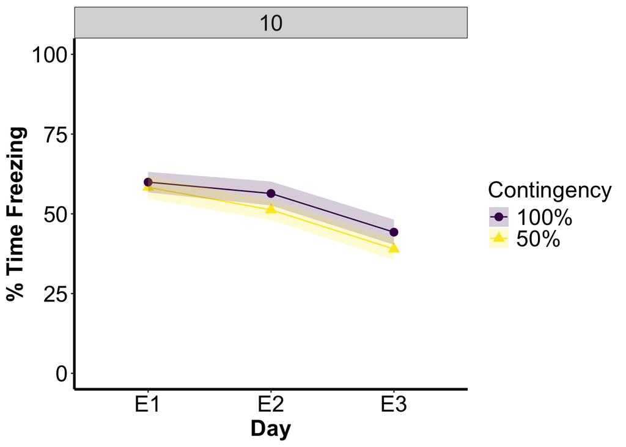

```r
ggplot(
  EXT_ave_2,
  aes(x=Exp_Type,
      y=group_mean_freezing,
      group = Contingency,
      color = Contingency,
      fill = Contingency,
      shape = Contingency)) +
  scale_fill_viridis(discrete = TRUE) +
  scale_colour_viridis(discrete = TRUE) +
  geom_point(
    size = 3
  ) +
  geom_line(
  ) +
  facet_wrap(
    vars(CS_Time)
  ) +
  ylim(0,100) +
  geom_ribbon(
    aes(
      ymin = group_mean_freezing-se,
      ymax = group_mean_freezing+se),
    alpha = .2,
    color = NA
  ) +
  theme_bw() +
  theme(legend.text=element_text(size=18),
        legend.title = element_text(size=18),
        panel.border= element_blank(),
        plot.background = element_blank(),
        plot.title = element_text(size = 18,face="bold.italic", hjust=0.5),
        panel.grid.major = element_blank(),
        panel.grid.minor = element_blank(),
        axis.text.x = element_text(size = 18, color="black"),
        axis.text.y = element_text(size = 18, color="black"),
        axis.title.x = element_text(size = 18, face= "bold"),
        axis.title.y = element_text(size = 18, face="bold"),
        axis.line.x = element_line(color="black", linewidth = 1),
        axis.line.y = element_line(color="black", linewidth = 1),
        strip.text = element_text(size = 18)) +
  labs(
    x = "Day",
    y = "% Time Freezing")
```

### E - Stats

```r
n2e <- emmeans(m2d, ~ Contingency* Exp_Type)
kable(pairs(n2e, simple=c("Exp_Type")), caption = '<b>Figure 2E: Simple Contrasts for Extinction Session</b>')
```

**Figure 2E: Simple Contrasts for Extinction Session**

| contrast | Contingency | estimate | SE | df | t.ratio | p.value |
| --- | --- | --- | --- | --- | --- | --- |
| E1 - E2 | 100% | 4.730069 | 4.450166 | 50 | 1.062897 | 0.5413004 |
| E1 - E3 | 100% | 17.012014 | 4.379190 | 50 | 3.884740 | 0.0008673 |
| E2 - E3 | 100% | 12.281944 | 3.231003 | 50 | 3.801279 | 0.0011238 |
| E1 - E2 | 50% | 7.071801 | 4.120053 | 50 | 1.716434 | 0.2091341 |
| E1 - E3 | 50% | 19.340327 | 4.054342 | 50 | 4.770275 | 0.0000480 |
| E2 - E3 | 50% | 12.268527 | 2.991327 | 50 | 4.101365 | 0.0004373 |

## F. Extinction Recall——————–

Extinction recall was measured at recent (48 h) or remote (30 d) timepoints. Mice were returned to Context B and received a tone test (4 CS presentations) 48 hours and 30 days after the last day of extinction training. In addition to comparing experimental groups at each time point, we also compared percent time freezing within-subjects between the recent and remote time points to assess the level of spontaneous recovery, or the return of conditioned fear with the passage of time

### F - Tidy

```r
ER_id_2 <- df %>%
  filter(str_detect(Component.Name, "pre-tone|post-tone", negate = TRUE),
         str_detect(CS_Time, "10"),
         str_detect(Trials, "6 Trials"),
         str_detect(Exp_Type, "ER")) %>%
  group_by(id, Group, CS_Time, Contingency, Exp_Type) %>%
  summarize(mean_freezing=mean(Pct.Component.Time.Freezing), n=n(),
            se=sd(Pct.Component.Time.Freezing/sqrt(n())))
```

```
## You can override using the `.groups` argument.
```

```r
ER_ave_2 <- ER_id_2 %>%
  group_by(CS_Time, Group, Contingency, Exp_Type) %>%
  summarize(group_mean_freezing=mean(mean_freezing), n=n(),
            se=sd(mean_freezing/sqrt(n())))
SR_id_2 <- df %>%
  filter(str_detect(Component.Name, "pre-tone|post-tone", negate = TRUE),
         str_detect(CS_Time, "10"),
         str_detect(Trials, "6 Trials"),
         str_detect(Exp_Type, "SR")) %>%
  group_by(id, Group, CS_Time, Contingency, Exp_Type) %>%
  summarize(mean_freezing=mean(Pct.Component.Time.Freezing), n=n(),
            se=sd(Pct.Component.Time.Freezing/sqrt(n())))
```

```
## You can override using the `.groups` argument.
```

```r
SR_ave_2 <- SR_id_2 %>%
  group_by(CS_Time, Group, Contingency, Exp_Type) %>%
  summarize(group_mean_freezing=mean(mean_freezing), n=n(),
            se=sd(mean_freezing/sqrt(n())))
ER_SR_id_2 <-rbind(ER_id_2, SR_id_2)
ER_SR_ave_2 <-rbind(ER_ave_2, SR_ave_2)
```

### F - Graph

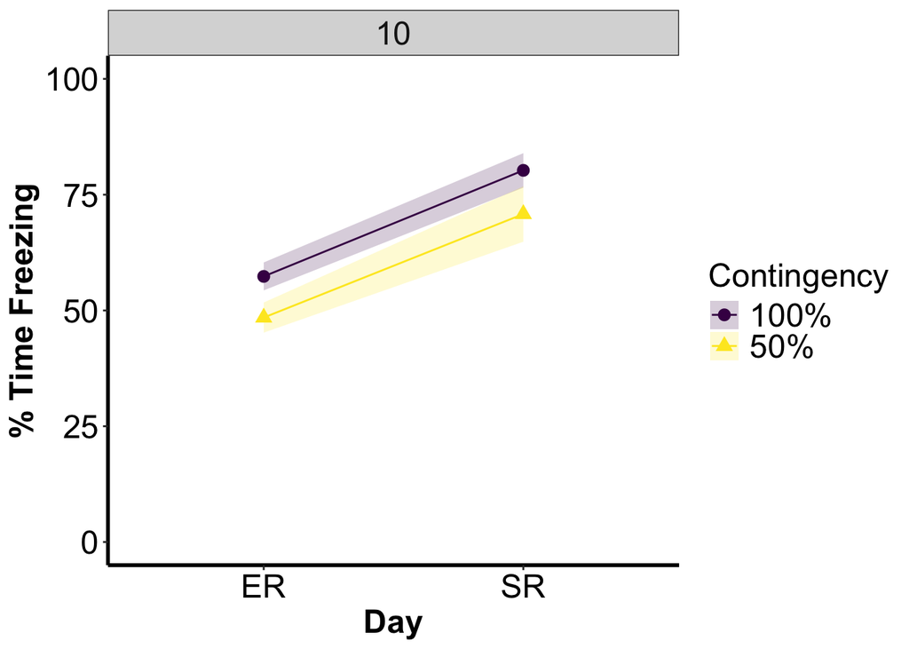

```r
ggplot(
  ER_SR_ave_2,
  aes(x=Exp_Type,
      y=group_mean_freezing,
      group = Contingency,
      color = Contingency,
      fill = Contingency,
      shape = Contingency)) +
  scale_fill_viridis(discrete = TRUE) +
  scale_colour_viridis(discrete = TRUE) +
  geom_point(
    size = 3
  ) +
  geom_line(
  ) +
  facet_wrap(
    vars(CS_Time)
  ) +
  ylim(0,100) +
  geom_ribbon(
    aes(
      ymin = group_mean_freezing-se,
      ymax = group_mean_freezing+se),
    alpha = .2,
    color = NA
  ) +
  theme_bw() +
  theme(legend.text=element_text(size=18),
        legend.title = element_text(size=18),
        panel.border= element_blank(),
        plot.background = element_blank(),
        plot.title = element_text(size = 18,face="bold.italic", hjust=0.5),
        panel.grid.major = element_blank(),
        panel.grid.minor = element_blank(),
        axis.text.x = element_text(size = 18, color="black"),
        axis.text.y = element_text(size = 18, color="black"),
        axis.title.x = element_text(size = 18, face= "bold"),
        axis.title.y = element_text(size = 18, face="bold"),
        axis.line.x = element_line(color="black", linewidth = 1),
        axis.line.y = element_line(color="black", linewidth = 1),
        strip.text = element_text(size = 18)) +
  labs(
    x = "Day",
    y = "% Time Freezing")
```

### F - Stats

```r
m2e <- ER_SR_id_2 %>%
  filter(Exp_Type != "E3") %>%
  aov_ez(id = "id",
         dv = "mean_freezing",
         between = "Contingency",
         within = "Exp_Type",
         data = .)
```

```
## Converting to factor: Contingency
```

```
## Contrasts set to contr.sum for the following variables: Contingency
```

```r
nice_m2e<- nice(m2e)

kable(nice_m2e, caption = '<b>Figure 2F</b>') %>%
  kable_styling(bootstrap_options = "striped", full_width = F, position = "left")
```

**Figure 2F**

| Effect | df | MSE | F | ges | p.value |
| --- | --- | --- | --- | --- | --- |
| Contingency | 1, 21 | 472.18 | 4.90 * | .149 | .038 |
| Exp_Type | 1, 21 | 154.83 | 52.01 *** | .379 | <.001 |
| Contingency:Exp_Type | 1, 21 | 154.83 | 1.68 | .019 | .209 |

```r
m2f <- emmeans(m2e, "Exp_Type", by = "Contingency")
n2f_pairs<- pairs(m2f, simple="each")

#Simple contrasts for recall day
kable(n2f_pairs[1], caption = '<b>Figure 2F: Simple contrasts for contingency</b>')
```

**Figure 2F: Simple contrasts for contingency**

| contrast | Contingency | estimate | SE | df | t.ratio | p.value |
| --- | --- | --- | --- | --- | --- | --- |
| ER - SR | 100% | -21.72250 | 5.079786 | 21 | -4.276263 | 0.0003356 |
| ER - SR | 50% | -31.25205 | 5.305663 | 21 | -5.890318 | 0.0000076 |

```r
#Simple contrasts for contingency
kable(n2f_pairs[2], caption = '<b>Figure 2F: Simple contrasts for contingency</b>')
```

**Figure 2F: Simple contrasts for contingency**

| contrast | Exp_Type | estimate | SE | df | t.ratio | p.value |
| --- | --- | --- | --- | --- | --- | --- |
| 100% - 50% | ER | 18.961742 | 7.840284 | 21 | 2.418502 | 0.0247528 |
| 100% - 50% | SR | 9.432197 | 6.912402 | 21 | 1.364532 | 0.1868448 |

# Fig 3. Lower US strength (0.3mA) & partial reinforcement alter fear learning but do not affect fear extinction.

The previous experiments failed to establish a PREE in fear learning in mice despite varying CS duration and the number of trials. One possible explanation for this was that the US strength used in previous protocols (0.75 mA) may have resulted in a ceiling effect, masking any effects of partial reinforcement on extinction. To avert this, we implemented a weaker US footshock (0.3 mA; Zweifel, 2019). To further maximize the possibility to detect PREE, if any, we also widened the range of contingencies in our study by introducing a 10% contingency protocol (Fig. 3A, Scheuer 1969). Our experimental design incorporated three groups with varying contingencies: a consistent reinforcement group (a 100% contingency: 3CS:3US pairing) and two partial reinforcement groups: a 50% contingency (6CS:3US pairing) and a 10% contingency (30CS:3US).

# Load and tidy data

Data was exported from VideoFreeze as CSV files. The header rows of the raw CSV files contain information regarding how the data was exported (ie how data was segmented into bins as well as what motion index threshold was used as a cut-off for assessing freezing).

```r
# df ---------------------------------------------------

list.files(path="./Figure_3_PREE_LowUS_10percent", pattern=".csv$", recursive = TRUE)
```

```
##  [1] "2022-10-25_PREE#14/22-10-25_FC1_10.csv"
##  [2] "2022-10-25_PREE#14/22-10-25_FC1_100.csv"
##  [3] "2022-10-25_PREE#14/22-10-26_FC2_10.csv"
##  [4] "2022-10-25_PREE#14/22-10-26_FC2_100.csv"
##  [5] "2022-10-25_PREE#14/22-10-27_E1.csv"
##  [6] "2022-10-25_PREE#14/22-10-28_E2.csv"
##  [7] "2022-10-25_PREE#14/22-10-29_E3.csv"
##  [8] "2022-10-25_PREE#14/22-10-31_ER.csv"
##  [9] "2022-10-25_PREE#14/22-11-28_SR.csv"
## [10] "2022-11-05_PREE#15/22-11-05_FC1.csv"
## [11] "2022-11-05_PREE#15/22-11-06_FC2.csv"
## [12] "2022-11-05_PREE#15/22-11-07_E1.csv"
## [13] "2022-11-05_PREE#15/22-11-08_E2.csv"
## [14] "2022-11-05_PREE#15/22-11-09_E3.csv"
## [15] "2022-11-05_PREE#15/22-11-11_ER.csv"
## [16] "2022-11-05_PREE#15/22-12-10_SR.csv"
## [17] "metadata.csv"
```

```r
list.filenames <- list.files(path="./Figure_3_PREE_LowUS_10percent", pattern = ".csv$",
                             full.names=TRUE, recursive = TRUE)
# delete the metadata from the list.filenames
list.filenames <- list.filenames[!(str_detect(list.filenames, "metadata"))]
list.filenames
```

```
##  [1] "./Figure_3_PREE_LowUS_10percent/2022-10-25_PREE#14/22-10-25_FC1_10.csv"
##  [2] "./Figure_3_PREE_LowUS_10percent/2022-10-25_PREE#14/22-10-25_FC1_100.csv"
##  [3] "./Figure_3_PREE_LowUS_10percent/2022-10-25_PREE#14/22-10-26_FC2_10.csv"
##  [4] "./Figure_3_PREE_LowUS_10percent/2022-10-25_PREE#14/22-10-26_FC2_100.csv"
##  [5] "./Figure_3_PREE_LowUS_10percent/2022-10-25_PREE#14/22-10-27_E1.csv"
##  [6] "./Figure_3_PREE_LowUS_10percent/2022-10-25_PREE#14/22-10-28_E2.csv"
##  [7] "./Figure_3_PREE_LowUS_10percent/2022-10-25_PREE#14/22-10-29_E3.csv"
##  [8] "./Figure_3_PREE_LowUS_10percent/2022-10-25_PREE#14/22-10-31_ER.csv"
##  [9] "./Figure_3_PREE_LowUS_10percent/2022-10-25_PREE#14/22-11-28_SR.csv"
## [10] "./Figure_3_PREE_LowUS_10percent/2022-11-05_PREE#15/22-11-05_FC1.csv"
## [11] "./Figure_3_PREE_LowUS_10percent/2022-11-05_PREE#15/22-11-06_FC2.csv"
## [12] "./Figure_3_PREE_LowUS_10percent/2022-11-05_PREE#15/22-11-07_E1.csv"
## [13] "./Figure_3_PREE_LowUS_10percent/2022-11-05_PREE#15/22-11-08_E2.csv"
## [14] "./Figure_3_PREE_LowUS_10percent/2022-11-05_PREE#15/22-11-09_E3.csv"
## [15] "./Figure_3_PREE_LowUS_10percent/2022-11-05_PREE#15/22-11-11_ER.csv"
## [16] "./Figure_3_PREE_LowUS_10percent/2022-11-05_PREE#15/22-12-10_SR.csv"
```

```r
metadata <- read.csv("./Figure_3_PREE_LowUS_10percent/metadata.csv")
list.data <- list()

for (i in 1:length(list.filenames)) {
  list.data[[i]] <- read.csv(list.filenames[[i]], skip=
                               ifelse(str_detect(list.filenames[[i]], "FC\\w*10.csv$"), 42,
                                      ifelse(str_detect(list.filenames[[i]], "FC\\w*100.csv$"), 15,
                                             ifelse(str_detect(list.filenames[[i]], "FC1.csv$"), 18,
                                                    ifelse(str_detect(list.filenames[[i]], "FC2.csv$"), 18,
                                                          ifelse(str_detect(list.filenames[[i]], "ER"), 16,
                                                                 ifelse(str_detect(list.filenames[[i]], "SR"), 16,
                                                                        24))))))
  )
  list.data[[i]]$ExpDetails <- str_sub(list.filenames[[i]], 52, -5)
  #remove the first and last characters
  list.data[[i]] <- dplyr::select(list.data[[i]], -c(Animal, Group))
}

list.data <- list.data %>%
  reduce(full_join) %>% #collapse separate items in list into one
  separate(col=ExpDetails, into = c("Exp_Date", "Exp_Type"), sep = "_")
```

[output not shown]

```r
# Conver list into a dataframe
df<-as.data.frame(list.data)
# Join df and metadata
df<- full_join(df, metadata,  by= c("Exp_Type", "Exp_Date", "Box", "Trial"))


df<- df%>%
  mutate(id= paste(Group, Cage, Animal, sep="_")) %>%
  mutate(Trial=as.factor(Trial)) %>%
  mutate(CS_Time=as.factor(CS_Time)) %>%
  mutate(Contingency=ifelse(
    str_detect(Group, "10$"), "10%",
    ifelse(str_detect(Group, "100$"),"100%",
           ifelse(str_detect(Group, "50$"),"50%", NA
                  ))))

rm(list=setdiff(ls(), "df"))
df<- df %>%
  drop_na(Trial, Strain, Experiment)

df$Contingency <- factor(df$Contingency, levels = c("100%", "50%", "10%"))
```

## B. Fear Acquisition——————–

### B - Dataframe

Compare the average percent time freezing during CS presentations across the two days of FC training

```r
FC_id_1 <- df %>%
  filter(str_detect(Component.Name, "pre-tone|post-tone", negate = TRUE),
         str_detect(Exp_Type, "FC")) %>%
  mutate(Condition = ifelse(
    str_detect(Exp_Type, "FC"), "FC", NA)) %>%
  group_by(id, Group, Contingency, Condition) %>%
  summarize(mean_freezing=mean(Pct.Component.Time.Freezing), n=n(),
            se=sd(Pct.Component.Time.Freezing/sqrt(n())))
FC_ave_1 <- FC_id_1 %>%
  group_by(Group, Contingency) %>%
  summarize(group_mean_freezing=mean(mean_freezing), n=n(),
            se=sd(mean_freezing/sqrt(n())))
#write_csv(FC_ave, "220803_PREE_FC_ave.csv")
```

### B - Graph

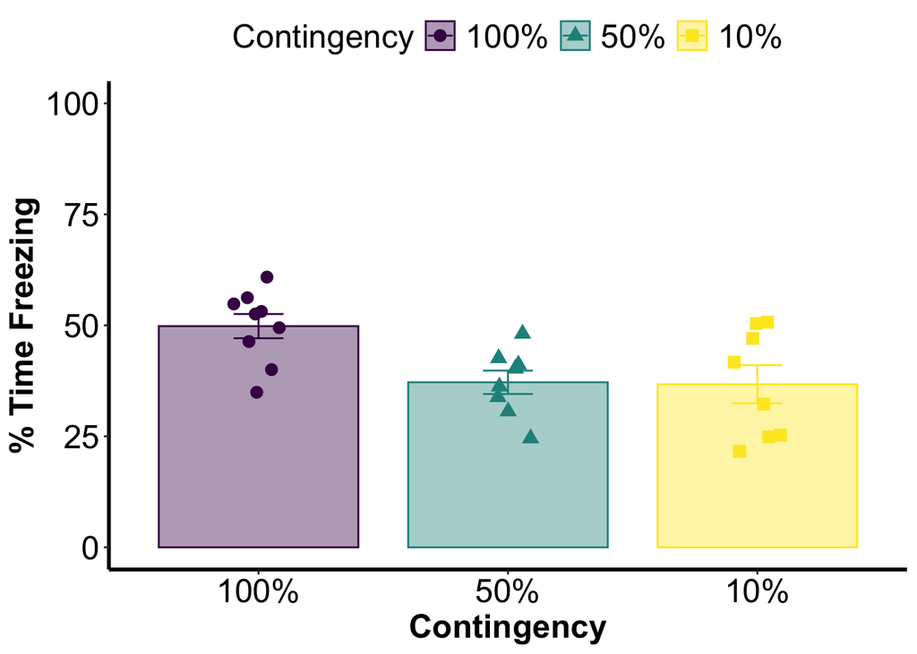

```r
ggplot(FC_ave_1,
       aes(x=Contingency,
           y=group_mean_freezing,
           group=Contingency,
           color=Contingency,
           fill=Contingency,
           shape=Contingency)) +
  scale_fill_viridis(discrete = TRUE) +
  scale_colour_viridis(discrete = TRUE) +
  geom_bar(
    stat = "identity",
    position = "dodge",
    width=0.8,
    alpha=0.4) +
  geom_errorbar(
    aes(
      ymin = group_mean_freezing-se,
      ymax = group_mean_freezing+se,
      width = .2),
    position=position_dodge(width=0.8)
  ) +
  geom_point(
    data=FC_id_1,
    aes(x=Contingency, y=mean_freezing),
    position = position_jitterdodge(jitter.height=0, jitter.width=0.5,
                                    dodge.width = 0.8),
    size=3
  ) +
  ylim(0,100) +
  theme_bw() +
  theme(legend.text=element_text(size=18),
        legend.title = element_text(size=18),
        legend.position = "top",
        panel.border= element_blank(),
        plot.background = element_blank(),
        plot.title = element_text(size = 18,face="bold.italic", hjust=0.5),
        panel.grid.major = element_blank(),
        panel.grid.minor = element_blank(),
        axis.text.x = element_text(size = 18, color="black"),
        axis.text.y = element_text(size = 18, color="black"),
        axis.title.x = element_text(size = 18, face= "bold"),
        axis.title.y = element_text(size = 18, face="bold"),
        axis.line.x = element_line(color="black", size = 1),
        axis.line.y = element_line(color="black", size = 1),
        strip.text = element_text(size = 18)) +
  labs(
    x = "Contingency",
    y = "% Time Freezing")
```

### B - Stats

```r
m3b <- FC_id_1 %>%
  aov_ez(id = "id",
         dv = "mean_freezing",
         between = "Contingency",
         within = ,
         data = .)
```

```
## Contrasts set to contr.sum for the following variables: Contingency
```

```r
#ANOVA table
nice_m3b <-nice(m3b)
kable(nice_m3b, caption = '<b>Figure 3B: Main FX</b>') %>%
  kable_styling(bootstrap_options = "striped", full_width = F, position = "left")
```

**Figure 3B: Main FX**

| Effect | df | MSE | F | ges | p.value |
| --- | --- | --- | --- | --- | --- |
| Contingency | 2, 22 | 89.01 | 5.36 * | .327 | .013 |

```r
#Simple contrasts for Contingency
n3b <- emmeans(m3b, ~Contingency)
n3b_pairs <- pairs(n3b, simple="Contingency")
kable(n3b_pairs, caption = '<b>Figure 3B: Simple Contrasts for Contingency</b>')
```

**Figure 3B: Simple Contrasts for Contingency**

| contrast | estimate | SE | df | t.ratio | p.value |
| --- | --- | --- | --- | --- | --- |
| 100% - 50% | 12.6397083 | 4.584378 | 22 | 2.7571261 | 0.0297352 |
| 100% - 10% | 13.0798750 | 4.584378 | 22 | 2.8531405 | 0.0241157 |
| 50% - 10% | 0.4401667 | 4.717286 | 22 | 0.0933093 | 0.9952124 |

## C. Fear Retrieval——————–

Retrieval was evaluated as the proportion of time freezing between two CS epochs: (1) CS freezing on FC Day 2 and (2) the first four CS presentations on Extinction Day 1

### C - Dataframe

```r
E1_Session1_id_1 <- df %>%
  filter(str_detect(Experiment, "E1"),
         str_detect(Experiment, "ER", negate = TRUE),
         str_detect(Component.Name,  "tone 01|tone 02|tone 03|tone 04")) %>%
  group_by(id, Group, CS_Time, Contingency, Exp_Type) %>%
  summarize(mean_freezing=mean(Pct.Component.Time.Freezing), n=n(),
            se=sd(Pct.Component.Time.Freezing/sqrt(n())))
```

```
## You can override using the `.groups` argument.
```

```r
E1_Session1_ave_1 <- E1_Session1_id_1 %>%
  group_by(CS_Time, Group, Contingency, Exp_Type) %>%
  summarize(group_mean_freezing=mean(mean_freezing), n=n(),
            se=sd(mean_freezing/sqrt(n())))
FC2_id_1 <- df %>%
  filter(str_detect(Component.Name, "pre-tone|post-tone", negate = TRUE),
         str_detect(Exp_Type, "FC2")) %>%
  group_by(id, Group, CS_Time, Contingency, Exp_Type) %>%
  summarize(mean_freezing=mean(Pct.Component.Time.Freezing), n=n(),
            se=sd(Pct.Component.Time.Freezing/sqrt(n())))
```

```
## You can override using the `.groups` argument.
```

```r
FC2_ave_1 <- FC2_id_1 %>%
  group_by(CS_Time, Group, Contingency, Exp_Type) %>%
  summarize(group_mean_freezing=mean(mean_freezing), n=n(),
            se=sd(mean_freezing/sqrt(n())))
E1_FC2_ave_1 <-rbind(E1_Session1_ave_1, FC2_ave_1)
E1_FC2_ave_1 <- E1_FC2_ave_1 %>%
  mutate(Exp_Type = if_else(Exp_Type == "E1", "Session 1", Exp_Type))

E1_FC2_id_1 <-rbind(E1_Session1_id_1, FC2_id_1)
E1_FC2_id_1 <- E1_FC2_id_1 %>%
  mutate(Exp_Type = if_else(Exp_Type == "E1", "Session 1", Exp_Type))
```

### C - Graph

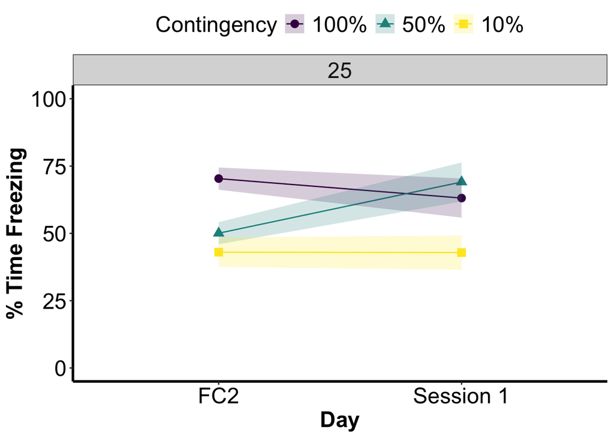

```r
ggplot(
  E1_FC2_ave_1,
  aes(x=Exp_Type,
      y=group_mean_freezing,
      group = Contingency,
      color = Contingency,
      fill = Contingency,
      shape = Contingency)) +
  scale_fill_viridis(discrete = TRUE) +
  scale_colour_viridis(discrete = TRUE) +
  geom_point(
    size = 3
  ) +
  geom_line(
  ) +
  facet_wrap(
    vars(CS_Time)
  ) +
  ylim(0,100) +
  geom_ribbon(
    aes(
      ymin = group_mean_freezing-se,
      ymax = group_mean_freezing+se),
    alpha = .2,
    color = NA
  ) +
  theme_bw() +
  theme(legend.text=element_text(size=18),
        legend.title = element_text(size=18),
        legend.position = "top",
        panel.border= element_blank(),
        plot.background = element_blank(),
        plot.title = element_text(size = 18,face="bold.italic", hjust=0.5),
        panel.grid.major = element_blank(),
        panel.grid.minor = element_blank(),
        axis.text.x = element_text(size = 18, color="black"),
        axis.text.y = element_text(size = 18, color="black"),
        axis.title.x = element_text(size = 18, face= "bold"),
        axis.title.y = element_text(size = 18, face="bold"),
        axis.line.x = element_line(color="black", size = 1),
        axis.line.y = element_line(color="black", size = 1),
        strip.text = element_text(size = 18)) +
  labs(
    x = "Day",
    y = "% Time Freezing")
```

### C - Stats

```r
m3c <- E1_FC2_id_1 %>%
  aov_ez(id = "id",
         dv = "mean_freezing",
         between = "Contingency",
         within = "Exp_Type",
         data = .)
```

```
## Contrasts set to contr.sum for the following variables: Contingency
```

```r
#ANOVA table
nice_m3c <-nice(m3c)
kable(nice_m3c, caption = '<b>Figure 3C: Main FX</b>') %>%
  kable_styling(bootstrap_options = "striped", full_width = F, position = "left")
```

**Figure 3C: Main FX**

| Effect | df | MSE | F | ges | p.value |
| --- | --- | --- | --- | --- | --- |
| Contingency | 2, 21 | 266.61 | 8.95 ** | .289 | .002 |
| Exp_Type | 1, 21 | 292.68 | 0.62 | .015 | .440 |
| Contingency:Exp_Type | 2, 21 | 292.68 | 2.52 | .112 | .104 |

```r
#Simple contrasts for Contingency
n3c <- emmeans(m3c, ~ Contingency)
n3c_pairs <- pairs(n3c, simple="Contingency")
kable(n3b_pairs, caption = '<b>Figure 3C: Simple Contrasts for Contingency</b>')
```

[output not shown]

## D. Extinction Acquisition——————–

To evaluate the effect of partial reinforcement on fear extinction acquisition, mice were exposed to 12 unreinforced CS presentations for three consecutive days (E1, E2, E3) in a novel context (Context B). Percent time freezing was averaged in bins composed of 3CS presentations.

### D - Dataframe

```r
bin1 =c("tone 01", "tone 02", "tone 03")
bin2 =c("tone 04", "tone 05", "tone 06")
bin3 =c("tone 07", "tone 08", "tone 09")
bin4 =c("tone 10", "tone 11", "tone 12")


EXT_bin_id_1 <- df %>%
  filter(str_detect(Experiment, "E"),
         str_detect(Experiment, "ER", negate = TRUE)) %>%
  mutate(Bin = ifelse(Component.Name %in% "pre-tone", "Pre",
                      ifelse(Component.Name %in% bin1, "1",
                             ifelse(Component.Name %in% bin2, "2",
                                    ifelse(Component.Name %in% bin3, "3",
                                           ifelse(Component.Name %in% bin4, "4", "Post")))))) %>%
  group_by(Exp_Type, id, Group, CS_Time, Contingency, Bin) %>%
  summarize(mean_freezing=mean(Pct.Component.Time.Freezing), n=n(),
            se=sd(Pct.Component.Time.Freezing/sqrt(n())))
```

```
## 'Contingency'. You can override using the `.groups` argument.
```

```r
EXT_bin_ave_1 <- EXT_bin_id_1 %>%
  group_by(Exp_Type, Bin, Group, CS_Time, Contingency) %>%
  summarize(group_mean_freezing=mean(mean_freezing), n=n(),
            se=sd(mean_freezing/sqrt(n())))
```

```
## can override using the `.groups` argument.
```

```r
EXT_bin_ave_1$Bin <- factor(EXT_bin_ave_1$Bin, levels = c("Pre", "1", "2", "3", "4", "5", "6", "Post"))
```

### D - Graph

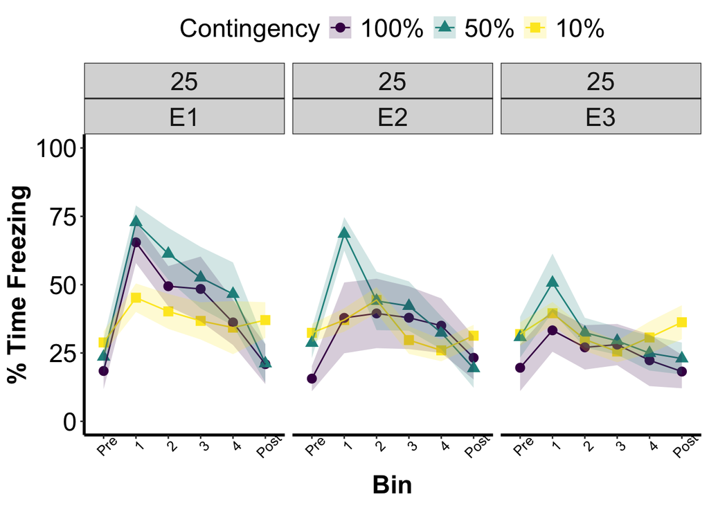

```r
ggplot(
  data = subset(EXT_bin_ave_1, !is.na(Bin)),
  aes(x=Bin,
      y=group_mean_freezing,
      group = Contingency,
      color = Contingency,
      fill = Contingency,
      shape=Contingency)) +
  facet_wrap(
    vars(CS_Time, Exp_Type)
  ) +
  scale_fill_viridis(discrete = TRUE) +
  scale_colour_viridis(discrete = TRUE) +
  geom_point(
    size = 3
  ) +
  geom_line(
  ) +
  ylim(0,100) +
  geom_ribbon(
    aes(
      ymin = group_mean_freezing-se,
      ymax = group_mean_freezing+se),
    alpha = .2,
    color = NA
  ) +
  theme_bw() +
  theme(legend.text=element_text(size=18),
        legend.title = element_text(size=18),
        legend.position = "top",
        panel.border= element_blank(),
        plot.background = element_blank(),
        plot.title = element_text(size = 18,face="bold.italic", hjust=0.5),
        panel.grid.major = element_blank(),
        panel.grid.minor = element_blank(),
        axis.text.x = element_text(size = 10, color="black", angle = 45),
        axis.text.y = element_text(size = 18, color="black"),
        axis.title.x = element_text(size = 18, face= "bold"),
        axis.title.y = element_text(size = 18, face="bold"),
        axis.line.x = element_line(color="black", size = 1),
        axis.line.y = element_line(color="black", size = 1),
        strip.text = element_text(size = 18)) +
  labs(
    x = "Bin",
    y = "% Time Freezing")
```

### D - Stats (ANOVA statistical analyses are represented in figs 1D-E )

```r
m3d <- EXT_bin_id_1 %>%
  filter(Bin != "Pre" & Bin !="Post") %>%
  aov_ez(id = "id",
         dv = "mean_freezing",
         between = "Contingency",
         within = c("Exp_Type", "Bin"),
         data = .)
```

```
## Contrasts set to contr.sum for the following variables: Contingency
```

```r
#ANOVA table
nice_m3d <-nice(m3d)
kable(nice_m3d, caption = '<b>Figure 3D: Main FX</b>') %>%
  kable_styling(bootstrap_options = "striped", full_width = F, position = "left")
```

**Figure 3D: Main FX**

| Effect | df | MSE | F | ges | p.value |
| --- | --- | --- | --- | --- | --- |
| Contingency | 2, 21 | 3381.18 | 1.00 | .048 | .385 |
| Exp_Type | 1.65, 34.74 | 869.77 | 10.75 *** | .103 | <.001 |
| Contingency:Exp_Type | 3.31, 34.74 | 869.77 | 0.90 | .019 | .460 |
| Bin | 2.67, 56.13 | 245.34 | 19.33 *** | .086 | <.001 |
| Contingency:Bin | 5.35, 56.13 | 245.34 | 2.41 * | .023 | .044 |
| Exp_Type:Bin | 2.95, 61.88 | 312.63 | 0.78 | .005 | .509 |
| Contingency:Exp_Type:Bin | 5.89, 61.88 | 312.63 | 1.26 | .017 | .291 |

```r
#Simple contrasts for Contingency and CS-bin
n3d <- emmeans(m3d, ~Contingency * Bin * Exp_Type)
n3d_pairs <- pairs(n3d, simple=c("Contingency", "Bin"))
kable(n3d_pairs, caption = '<b>Figure 3D: Simple Contrasts for Contingency and CS-Bin</b>')
```

**Figure 3D: Simple Contrasts for Contingency and CS-Bin**

| contrast | Exp_Type | estimate | SE | df | t.ratio | p.value |
| --- | --- | --- | --- | --- | --- | --- |
| 100% X1 - 50% X1 | E1 | -7.3683333 | 9.025929 | 21 | -0.8163518 | 0.9993092 |
| 100% X1 - 10% X1 | E1 | 20.2541667 | 9.025929 | 21 | 2.2439980 | 0.5392013 |
| 100% X1 - 100% X2 | E1 | 16.0491667 | 4.361782 | 21 | 3.6794975 | 0.0476341 |
| 100% X1 - 50% X2 | E1 | 4.1929167 | 10.134359 | 21 | 0.4137328 | 0.9999992 |
| 100% X1 - 10% X2 | E1 | 25.2591667 | 10.134359 | 21 | 2.4924287 | 0.3942497 |
| 100% X1 - 100% X3 | E1 | 17.0425000 | 7.478550 | 21 | 2.2788509 | 0.5179400 |
| 100% X1 - 50% X3 | E1 | 12.9158333 | 12.052033 | 21 | 1.0716726 | 0.9928991 |
| 100% X1 - 10% X3 | E1 | 28.7320833 | 12.052033 | 21 | 2.3840031 | 0.4553318 |
| 100% X1 - 100% X4 | E1 | 29.3050000 | 7.757349 | 21 | 3.7777079 | 0.0388471 |
| 100% X1 - 50% X4 | E1 | 18.8879167 | 11.808316 | 21 | 1.5995436 | 0.8910047 |
| 100% X1 - 10% X4 | E1 | 31.1879167 | 11.808316 | 21 | 2.6411823 | 0.3180565 |
| 50% X1 - 10% X1 | E1 | 27.6225000 | 9.025929 | 21 | 3.0603498 | 0.1586247 |
| 50% X1 - 100% X2 | E1 | 23.4175000 | 10.134359 | 21 | 2.3107036 | 0.4986988 |
| 50% X1 - 50% X2 | E1 | 11.5612500 | 4.361782 | 21 | 2.6505794 | 0.3135745 |
| 50% X1 - 10% X2 | E1 | 32.6275000 | 10.134359 | 21 | 3.2194932 | 0.1183667 |
| 50% X1 - 100% X3 | E1 | 24.4108333 | 12.052033 | 21 | 2.0254536 | 0.6736356 |
| 50% X1 - 50% X3 | E1 | 20.2841667 | 7.478550 | 21 | 2.7123128 | 0.2851598 |
| 50% X1 - 10% X3 | E1 | 36.1004167 | 12.052033 | 21 | 2.9953799 | 0.1780380 |
| 50% X1 - 100% X4 | E1 | 36.6733333 | 11.808316 | 21 | 3.1057207 | 0.1461260 |
| 50% X1 - 50% X4 | E1 | 26.2562500 | 7.757349 | 21 | 3.3846935 | 0.0862001 |
| 50% X1 - 10% X4 | E1 | 38.5562500 | 11.808316 | 21 | 3.2651776 | 0.1085652 |
| 10% X1 - 100% X2 | E1 | -4.2050000 | 10.134359 | 21 | -0.4149251 | 0.9999992 |
| 10% X1 - 50% X2 | E1 | -16.0612500 | 10.134359 | 21 | -1.5848314 | 0.8964561 |
| 10% X1 - 10% X2 | E1 | 5.0050000 | 4.361782 | 21 | 1.1474667 | 0.9879050 |
| 10% X1 - 100% X3 | E1 | -3.2116667 | 12.052033 | 21 | -0.2664834 | 1.0000000 |
| 10% X1 - 50% X3 | E1 | -7.3383333 | 12.052033 | 21 | -0.6088876 | 0.9999575 |
| 10% X1 - 10% X3 | E1 | 8.4779167 | 7.478550 | 21 | 1.1336311 | 0.9889767 |
| 10% X1 - 100% X4 | E1 | 9.0508333 | 11.808316 | 21 | 0.7664796 | 0.9996130 |
| 10% X1 - 50% X4 | E1 | -1.3662500 | 11.808316 | 21 | -0.1157024 | 1.0000000 |
| 10% X1 - 10% X4 | E1 | 10.9337500 | 7.757349 | 21 | 1.4094699 | 0.9487244 |

[output cut: 168 more lines]

## E. Extinction Consolidation——————–

We investigated whether partial reinforcement could affect 24-hr consolidation of extinction learning across the three extinction sessions. For this analysis we averaged percent time freezing across all CS presentations per extinction training day.

### E - Dataframe

```r
EXT_id_1 <- df %>%
  filter(str_detect(Component.Name, "pre-tone|post-tone", negate = TRUE),
         str_detect(Exp_Type, "E"),
         str_detect(Exp_Type, "ER", negate = TRUE)) %>%
  group_by(Exp_Type, id, Group, CS_Time, Contingency) %>%
  summarize(mean_freezing=mean(Pct.Component.Time.Freezing), n=n(),
            se=sd(Pct.Component.Time.Freezing/sqrt(n())))
```

```
## can override using the `.groups` argument.
```

```r
EXT_ave_1 <- EXT_id_1 %>%
  group_by(Exp_Type, CS_Time, Group, Contingency) %>%
  summarize(group_mean_freezing=mean(mean_freezing), n=n(),
            se=sd(mean_freezing/sqrt(n())))
```

### E - Graph

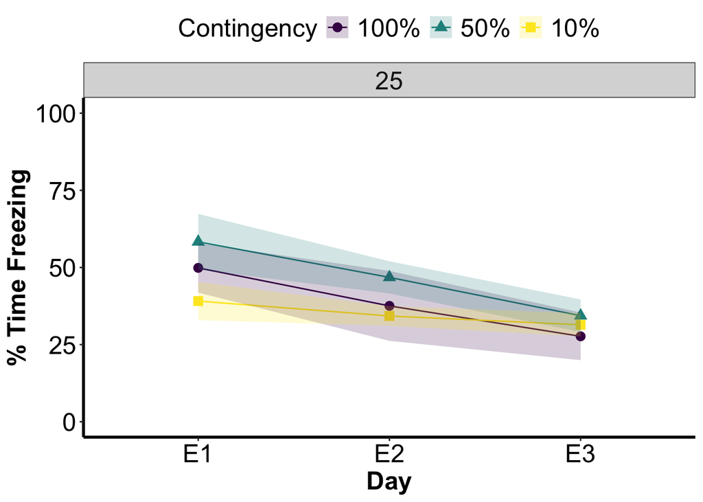

```r
ggplot(
  EXT_ave_1,
  aes(x=Exp_Type,
      y=group_mean_freezing,
      group = Contingency,
      color = Contingency,
      fill = Contingency,
      shape = Contingency)) +
  scale_fill_viridis(discrete = TRUE) +
  scale_colour_viridis(discrete = TRUE) +
  geom_point(
    size = 3
  ) +
  geom_line(
  ) +
  facet_wrap(
    vars(CS_Time)
  ) +
  ylim(0,100) +
  geom_ribbon(
    aes(
      ymin = group_mean_freezing-se,
      ymax = group_mean_freezing+se),
    alpha = .2,
    color = NA
  ) +
  theme_bw() +
  theme(legend.text=element_text(size=18),
        legend.title = element_text(size=18),
        legend.position = "top",
        panel.border= element_blank(),
        plot.background = element_blank(),
        plot.title = element_text(size = 18,face="bold.italic", hjust=0.5),
        panel.grid.major = element_blank(),
        panel.grid.minor = element_blank(),
        axis.text.x = element_text(size = 18, color="black"),
        axis.text.y = element_text(size = 18, color="black"),
        axis.title.x = element_text(size = 18, face= "bold"),
        axis.title.y = element_text(size = 18, face="bold"),
        axis.line.x = element_line(color="black", size = 1),
        axis.line.y = element_line(color="black", size = 1),
        strip.text = element_text(size = 18)) +
  labs(
    x = "Day",
    y = "% Time Freezing")
```

### E - Stats

```r
#Simple contrasts for Extinction Session
n3e <- emmeans(m3d, ~ Exp_Type)
n3e_pairs <- pairs(n3e, simple=c("Exp_Type"))
kable(n3e_pairs, caption = '<b>Figure 3E: Simple Contrasts for Extinction Session</b>')
```

**Figure 3E: Simple Contrasts for Extinction Session**

| contrast | estimate | SE | df | t.ratio | p.value |
| --- | --- | --- | --- | --- | --- |
| E1 - E2 | 9.555035 | 4.214608 | 21 | 2.267123 | 0.0829928 |
| E1 - E3 | 17.939028 | 4.361975 | 21 | 4.112593 | 0.0013827 |
| E2 - E3 | 8.383993 | 2.859560 | 21 | 2.931917 | 0.0208527 |

## F. Extinction Recall——————–

Extinction recall was measured at recent (48 h) or remote (30 d) timepoints. Mice were returned to Context B and received a tone test (4 CS presentations) 48 hours and 30 days after the last day of extinction training. In addition to comparing experimental groups at each time point, we also compared percent time freezing within-subjects between the recent and remote time points to assess the level of spontaneous recovery, or the return of conditioned fear with the passage of time

### F - Dataframe

```r
ER_id_1 <- df %>%
  filter(str_detect(Component.Name, "pre-tone|post-tone", negate = TRUE),
         str_detect(Exp_Type, "ER")) %>%
  group_by(id, Group, CS_Time, Contingency, Exp_Type) %>%
  summarize(mean_freezing=mean(Pct.Component.Time.Freezing), n=n(),
            se=sd(Pct.Component.Time.Freezing/sqrt(n())))
```

```
## You can override using the `.groups` argument.
```

```r
ER_ave_1 <- ER_id_1 %>%
  group_by(CS_Time, Group, Contingency, Exp_Type) %>%
  summarize(group_mean_freezing=mean(mean_freezing), n=n(),
            se=sd(mean_freezing/sqrt(n())))
E3_id_1 <- df %>%
  filter(str_detect(Component.Name, "pre-tone|post-tone", negate = TRUE),
         str_detect(Exp_Type, "E3")) %>%
  group_by(id, Group, CS_Time, Contingency, Exp_Type) %>%
  summarize(mean_freezing=mean(Pct.Component.Time.Freezing), n=n(),
            se=sd(Pct.Component.Time.Freezing/sqrt(n())))
```

```
## You can override using the `.groups` argument.
```

```r
E3_ave_1 <- E3_id_1 %>%
  group_by(CS_Time, Group, Contingency, Exp_Type) %>%
  summarize(group_mean_freezing=mean(mean_freezing), n=n(),
            se=sd(mean_freezing/sqrt(n())))
SR_id_1 <- df %>%
  filter(str_detect(Component.Name, "pre-tone|post-tone", negate = TRUE),
         str_detect(Exp_Type, "SR")) %>%
  group_by(id, Group, CS_Time, Contingency, Exp_Type) %>%
  summarize(mean_freezing=mean(Pct.Component.Time.Freezing), n=n(),
            se=sd(Pct.Component.Time.Freezing/sqrt(n())))
```

```
## You can override using the `.groups` argument.
```

```r
SR_ave_1 <- SR_id_1 %>%
  group_by(CS_Time, Group, Contingency, Exp_Type) %>%
  summarize(group_mean_freezing=mean(mean_freezing), n=n(),
            se=sd(mean_freezing/sqrt(n())))
E3_ER_SR_ave_1 <-rbind(E3_ave_1, ER_ave_1, SR_ave_1)
E3_ER_SR_id_1 <-rbind(E3_id_1, ER_id_1, SR_id_1)
```

### F - Graph

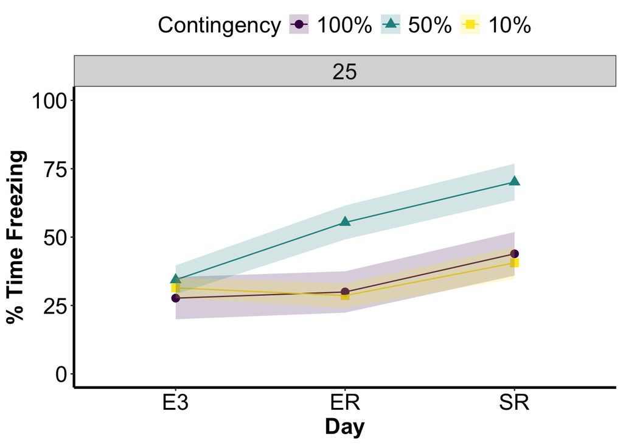

```r
ggplot(
  E3_ER_SR_ave_1,
  aes(x=Exp_Type,
      y=group_mean_freezing,
      group = Contingency,
      color = Contingency,
      fill = Contingency,
      shape = Contingency)) +
  scale_fill_viridis(discrete = TRUE) +
  scale_colour_viridis(discrete = TRUE) +
  geom_point(
    size = 3
  ) +
  geom_line(
  ) +
  facet_wrap(
    vars(CS_Time)
  ) +
  ylim(0,100) +
  geom_ribbon(
    aes(
      ymin = group_mean_freezing-se,
      ymax = group_mean_freezing+se),
    alpha = .2,
    color = NA
  ) +
  theme_bw() +
  theme(legend.text=element_text(size=18),
        legend.title = element_text(size=18),
        legend.position = "top",
        panel.border= element_blank(),
        plot.background = element_blank(),
        plot.title = element_text(size = 18,face="bold.italic", hjust=0.5),
        panel.grid.major = element_blank(),
        panel.grid.minor = element_blank(),
        axis.text.x = element_text(size = 18, color="black"),
        axis.text.y = element_text(size = 18, color="black"),
        axis.title.x = element_text(size = 18, face= "bold"),
        axis.title.y = element_text(size = 18, face="bold"),
        axis.line.x = element_line(color="black", size = 1),
        axis.line.y = element_line(color="black", size = 1),
        strip.text = element_text(size = 18)) +
  labs(
    x = "Day",
    y = "% Time Freezing")
```

### F - Stats

```r
m3f <- E3_ER_SR_id_1 %>%
  filter(Exp_Type !="E3") %>%
  aov_ez(id = "id",
         dv = "mean_freezing",
         between = "Contingency",
         within = "Exp_Type",
         data = .)
```

```
## Contrasts set to contr.sum for the following variables: Contingency
```

```r
#ANOVA table
nice_m3f <-nice(m3f)
kable(nice_m3f, caption = '<b>Figure 3F: Main FX</b>') %>%
  kable_styling(bootstrap_options = "striped", full_width = F, position = "left")
```

**Figure 3F: Main FX**

| Effect | df | MSE | F | ges | p.value |
| --- | --- | --- | --- | --- | --- |
| Contingency | 2, 21 | 345.52 | 11.31 *** | .351 | <.001 |
| Exp_Type | 1, 21 | 344.32 | 6.42 * | .132 | .019 |
| Contingency:Exp_Type | 2, 21 | 344.32 | 0.02 | .001 | .976 |

```r
#Simple contrasts for Contingency and Tone Test Day
n3f <- emmeans(m3f, ~Contingency * Exp_Type)
n3f_pairs <- pairs(n3f, simple="each")
kable(n3f_pairs[1], caption = '<b>Figure 3F: Simple Contrasts for Contingency</b>')
```

**Figure 3F: Simple Contrasts for Contingency**

| contrast | Exp_Type | estimate | SE | df | t.ratio | p.value |
| --- | --- | --- | --- | --- | --- | --- |
| 100% - 50% | ER | -25.420938 | 8.80355 | 21 | -2.8875782 | 0.0229734 |
| 100% - 10% | ER | 1.330625 | 8.80355 | 21 | 0.1511464 | 0.9874919 |
| 50% - 10% | ER | 26.751562 | 8.80355 | 21 | 3.0387246 | 0.0164774 |
| 100% - 50% | SR | -26.254375 | 9.74471 | 21 | -2.6942183 | 0.0348063 |
| 100% - 10% | SR | 3.313125 | 9.74471 | 21 | 0.3399922 | 0.9384542 |
| 50% - 10% | SR | 29.567500 | 9.74471 | 21 | 3.0342105 | 0.0166432 |

```r
kable(n3f_pairs[2], caption = '<b>Figure 3F: Simple Contrasts for Tone Test Day</b>')
```

**Figure 3F: Simple Contrasts for Tone Test Day**

| contrast | Contingency | estimate | SE | df | t.ratio | p.value |
| --- | --- | --- | --- | --- | --- | --- |
| ER - SR | 100% | -13.95813 | 9.277987 | 21 | -1.504435 | 0.1473619 |
| ER - SR | 50% | -14.79156 | 9.277987 | 21 | -1.594264 | 0.1258177 |
| ER - SR | 10% | -11.97563 | 9.277987 | 21 | -1.290757 | 0.2108182 |

# Fig 4 B-C: Reducing the number of Fear Conditioning Sessions to 1

Previous studies have found that the over-training may occlude the PREE (Hilton 1969; Sutherland et al 1965). To address the possibility that this was occuring in our experiments, we reduced the fear conditioning protocol from two days to one (see Fig. 4A).

# Load and tidy data

Data was exported from VideoFreeze as CSV files. The header rows of the raw CSV files contain information regarding how the data was exported (ie how data was segmented into bins as well as what motion index threshold was used as a cut-off for assessing freezing).

```r
# df ---------------------------------------------------

list.files(path="./Figure_4B-C_OneFC", pattern=".csv$", recursive = TRUE)
```

```
## [1] "2024-04-04_FC1_R1_PR.csv" "2024-04-04_FC1_R2_CR.csv"
## [3] "2024-04-05_E1_R1_NA.csv"  "2024-04-05_E1_R2_NA.csv"
```

```r
list.filenames <- list.files(path="./Figure_4B-C_OneFC", pattern = ".csv$",
                             full.names=TRUE, recursive = TRUE)
# delete the metadata from the list.filenames
list.data <- list()

for (i in 1:length(list.filenames)) {
  list.data[[i]] <- read.csv(list.filenames[[i]], skip=
                               ifelse(str_detect(list.filenames[[i]], "FC\\w*CR.csv$"), 15,
                                      ifelse(str_detect(list.filenames[[i]], "FC\\w*PR.csv$"), 18,
                                                    ifelse(str_detect(list.filenames[[i]], "E1"), 24,
                                                           ifelse(str_detect(list.filenames[[i]], "SR"), 16,
                                                                  24))))
  )
  list.data[[i]]$ExpDetails <- str_sub(list.filenames[[i]], 21, -5)

}

list.data <- list.data %>%
  reduce(full_join) %>% #collapse separate items in list into one
  separate(col=ExpDetails, into = c("Exp_Date", "Exp_Type", "Exp_Room", "Exp_Sched"), sep = "_") %>%
  mutate(id = Animal) %>%
  separate(col = Animal, into = c("Strain", "Sex", "Cage", "Chamber"), sep = "-")
```

[output not shown]

```r
# Conver list into a dataframe
df<-as.data.frame(list.data) %>%  filter(Trial != "NA")

rm(list=setdiff(ls(), "df"))
# df<- df %>%
#   drop_na(Trial, Strain, Experiment)

#write_csv(df, "220803_PREE_df.csv")
```

## B. Fear Acquisition——————–

### B - Dataframe

```r
FC_id_1 <- df %>%
  filter(str_detect(Component.Name, "pre-tone|post-tone", negate = TRUE),
         str_detect(Exp_Type, "FC")) %>%
  group_by(id, Group) %>%
  summarize(mean_freezing=mean(Pct.Component.Time.Freezing), n=n(),
            se=sd(Pct.Component.Time.Freezing/sqrt(n())))
```

```
## argument.
```

```r
#write_csv(FC_id, "220803_PREE_FC_id.csv")

FC_ave_1 <- FC_id_1 %>%
  group_by(Group) %>%
  summarize(group_mean_freezing=mean(mean_freezing), n=n(),
            se=sd(mean_freezing/sqrt(n())))

#write_csv(FC_ave, "220803_PREE_FC_ave.csv")
```

### B - Graph

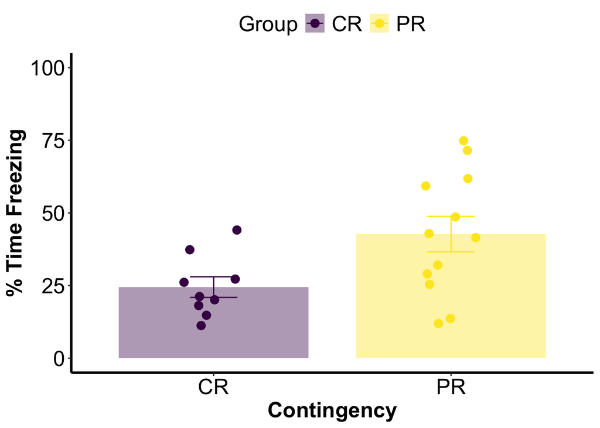

```r
ggplot(FC_ave_1,
       aes(x=Group,
           y=group_mean_freezing,
           group=Group,
           color=Group,
           fill=Group)) +
  scale_fill_viridis(discrete = TRUE) +
  scale_colour_viridis(discrete = TRUE) +
  geom_bar(
    stat = "identity",
    position = "dodge",
    width=0.8,
    alpha=0.4,
    color=NA) +
  geom_errorbar(
    aes(
      ymin = group_mean_freezing-se,
      ymax = group_mean_freezing+se,
      width = .2),
    position=position_dodge(width=0.8)
  ) +
  geom_point(
    data=FC_id_1,
    aes(x=Group, y=mean_freezing),
    position = position_jitterdodge(jitter.height=0, jitter.width=0.25,
                                    dodge.width = 0.8),
    size=3
  ) +
  ylim(0,100) +
  theme_bw() +
  theme(legend.text=element_text(size=18),
        legend.title = element_text(size=18),
        legend.position = "top",
        panel.border= element_blank(),
        plot.background = element_blank(),
        plot.title = element_text(size = 18,face="bold.italic", hjust=0.5),
        panel.grid.major = element_blank(),
        panel.grid.minor = element_blank(),
        axis.text.x = element_text(size = 18, color="black"),
        axis.text.y = element_text(size = 18, color="black"),
        axis.title.x = element_text(size = 18, face= "bold"),
        axis.title.y = element_text(size = 18, face="bold"),
        axis.line.x = element_line(color="black", size = 1),
        axis.line.y = element_line(color="black", size = 1),
        strip.text = element_text(size = 18)) +
  labs(
    x = "Contingency",
    y = "% Time Freezing")
```

### B - Stats

Sex was originally in the statistical model: mean_freezing ~ Contingency (2) X CS_time (2) X Sex (2). However, considering broad lack of sex-specific effects, it was dropped from models.

```r
m4b <- FC_id_1 %>%
  aov_ez(id = "id",
         dv = "mean_freezing",
         between = c("Group"),
         data = .)
```

```
## Converting to factor: Group
```

```
## Contrasts set to contr.sum for the following variables: Group
```

```r
#ANOVA table
nice_m4b <-nice(m4b)
kable(nice_m4b, caption = '<b>Figure 4B: Main FX</b>') %>%
  kable_styling(bootstrap_options = "striped", full_width = F, position = "left")
```

**Figure 4B: Main FX**

| Effect | df | MSE | F | ges | p.value |
| --- | --- | --- | --- | --- | --- |
| Group | 1, 19 | 306.85 | 5.58 * | .227 | .029 |

## C. Extinction Acquisition——————–

### C - Dataframe

```r
bin1 =c("tone 01", "tone 02", "tone 03")
bin2 =c("tone 04", "tone 05", "tone 06")
bin3 =c("tone 07", "tone 08", "tone 09")
bin4 =c("tone 10", "tone 11", "tone 12")

EXT_bin_id_1 <- df %>%
  filter(str_detect(Experiment, "E1")) %>%
  mutate(Bin = ifelse(Component.Name %in% "pre-tone", "Pre",
                      ifelse(Component.Name %in% bin1, "1",
                             ifelse(Component.Name %in% bin2, "2",
                                    ifelse(Component.Name %in% bin3, "3",
                                           ifelse(Component.Name %in% bin4, "4", "Post")))))) %>%
  group_by(Exp_Type, id, Group, Bin) %>%
  summarize(mean_freezing=mean(Pct.Component.Time.Freezing), n=n(),
            se=sd(Pct.Component.Time.Freezing/sqrt(n())))
EXT_bin_ave_1 <- EXT_bin_id_1 %>%
  group_by(Group, Bin) %>%
  summarize(group_mean_freezing=mean(mean_freezing), n=n(),
            se=sd(mean_freezing/sqrt(n())))
EXT_bin_ave_1$Bin <- factor(EXT_bin_ave_1$Bin, levels = c("Pre", "1", "2", "3", "4", "Post"))
```

### C - Graph

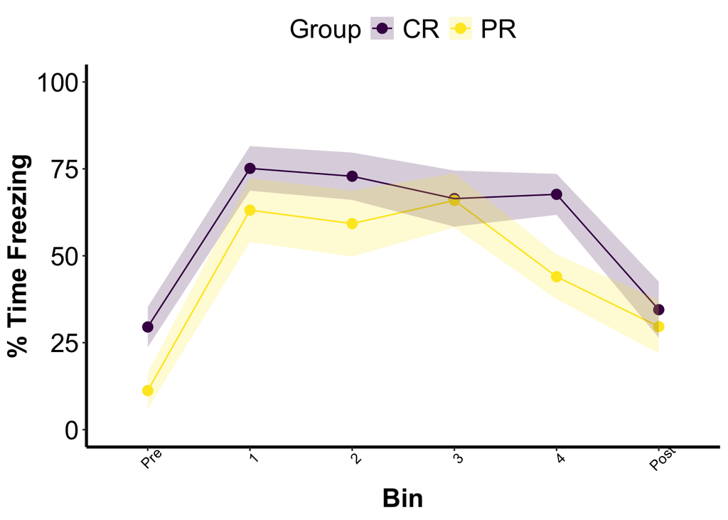

```r
ggplot(
  data = subset(EXT_bin_ave_1, !is.na(Bin)),
  aes(x=Bin,
      y=group_mean_freezing,
      group = interaction(Group),
      color = Group,
      fill = Group)) +
  scale_fill_viridis(discrete = TRUE) +
  scale_colour_viridis(discrete = TRUE) +
  geom_point(
    size = 3
  ) +
  geom_line(
  ) +
  ylim(0,100) +
  geom_ribbon(
    aes(
      ymin = group_mean_freezing-se,
      ymax = group_mean_freezing+se),
    alpha = .2,
    color = NA
  ) +
  theme_bw() +
  theme(legend.text=element_text(size=18),
        legend.title = element_text(size=18),
        legend.position = "top",
        panel.border= element_blank(),
        plot.background = element_blank(),
        plot.title = element_text(size = 18,face="bold.italic", hjust=0.5),
        panel.grid.major = element_blank(),
        panel.grid.minor = element_blank(),
        axis.text.x = element_text(size = 10, color="black", angle = 45),
        axis.text.y = element_text(size = 18, color="black"),
        axis.title.x = element_text(size = 18, face= "bold"),
        axis.title.y = element_text(size = 18, face="bold"),
        axis.line.x = element_line(color="black", linewidth = 1),
        axis.line.y = element_line(color="black", linewidth = 1),
        strip.text = element_text(size = 18)) +
  labs(
    x = "Bin",
    y = "% Time Freezing")
```

### C - Stats (ANOVA statistical analyses are represented in figs 1D-E )

```r
###### FE1 ############
m4c.FE <- EXT_bin_id_1 %>%
  filter(str_detect(Bin, "Pre|Post", negate = TRUE)) %>%
  # filter(Exp_Type == "E1") %>%
  aov_ez(id = "id",
         dv = "mean_freezing",
         between = c("Group"),
         within = c("Bin"),
         # covariate = "Exp_Type", factorize=FALSE,
         data = .)
```

```
## Converting to factor: Group
```

```
## Contrasts set to contr.sum for the following variables: Group
```

```r
#ANOVA table
nice_m4c <-nice(m4c.FE)
kable(nice_m4c, caption = '<b>Figure 4C: Main FX</b>') %>%
  kable_styling(bootstrap_options = "striped", full_width = F, position = "left")
```

**Figure 4C: Main FX**

| Effect | df | MSE | F | ges | p.value |
| --- | --- | --- | --- | --- | --- |
| Group | 1, 15 | 1258.84 | 2.09 | .083 | .169 |
| Bin | 2.69, 40.29 | 250.87 | 2.56 + | .056 | .075 |
| Group:Bin | 2.69, 40.29 | 250.87 | 1.70 | .038 | .187 |

# Fig 4. Testing effect of interpolated extinction (E-F)

We attempted to stimulate a PREE using an interpolated CS session (Fig. 4D). We based this approach on a previous study which inflated the PREE by interpolating a block of non-reinforced trials (20 CSs) in the conditioning phase with the rationale of enhancing the effect of nonreinforcement (Hilton 1969).

# Load and tidy data

Data was exported from VideoFreeze as CSV files. The header rows of the raw CSV files contain information regarding how the data was exported (ie how data was segmented into bins as well as what motion index threshold was used as a cut-off for assessing freezing).

```r
# df ---------------------------------------------------

list.files(path="./Figure_4E-F_Interpolated Extinction", pattern=".csv$", recursive = TRUE)
```

```
##  [1] "PREE_INTERPOLATE/PREE #16/2024-03-30_FC1_R1_CR.csv"
##  [2] "PREE_INTERPOLATE/PREE #16/2024-03-30_FC1_R1_PR.csv"
##  [3] "PREE_INTERPOLATE/PREE #16/2024-03-30_FC1_R2_CR.csv"
##  [4] "PREE_INTERPOLATE/PREE #16/2024-03-30_FC1_R2_PR.csv"
##  [5] "PREE_INTERPOLATE/PREE #16/2024-03-31_IPE_R1_NA.csv"
##  [6] "PREE_INTERPOLATE/PREE #16/2024-03-31_IPE_R2_NA.csv"
##  [7] "PREE_INTERPOLATE/PREE #16/2024-04-01_FC2_R1_CR.csv"
##  [8] "PREE_INTERPOLATE/PREE #16/2024-04-01_FC2_R1_PR.csv"
##  [9] "PREE_INTERPOLATE/PREE #16/2024-04-01_FC2_R2_CR.csv"
## [10] "PREE_INTERPOLATE/PREE #16/2024-04-01_FC2_R2_PR.csv"
## [11] "PREE_INTERPOLATE/PREE #16/2024-04-02_E1_R1_NA.csv"
## [12] "PREE_INTERPOLATE/PREE #16/2024-04-02_E1_R2_NA.csv"
```

```r
list.filenames <- list.files(path="./Figure_4E-F_Interpolated Extinction", pattern = ".csv$",
                             full.names=TRUE, recursive = TRUE)
# delete the metadata from the list.filenames
list.data <- list()

for (i in 1:length(list.filenames)) {
  list.data[[i]] <- read.csv(list.filenames[[i]], skip=
                               ifelse(str_detect(list.filenames[[i]], "FC\\w*CR.csv$"), 15,
                                      ifelse(str_detect(list.filenames[[i]], "FC\\w*PR.csv$"), 18,
                                             ifelse(str_detect(list.filenames[[i]], "IPE"), 32,
                                                    ifelse(str_detect(list.filenames[[i]], "E1"), 24,
                                                           ifelse(str_detect(list.filenames[[i]], "SR"), 16,
                                                                  24)))))
  )
  list.data[[i]]$ExpDetails <- str_sub(list.filenames[[i]], 67, -5)

}

list.data <- list.data %>%
  reduce(full_join) %>% #collapse separate items in list into one
  separate(col=ExpDetails, into = c("Exp_Date", "Exp_Type", "Exp_Room", "Exp_Sched"), sep = "_") %>%
  separate(col=Group, into = c("R_Schedule", "Interpolated"), sep = "_") %>%
  mutate(id = Animal) %>%
  separate(col = Animal, into = c("Strain", "Sex", "Cage", "Chamber"), sep = "-")
```

[output not shown]

```r
# Conver list into a dataframe
df<-as.data.frame(list.data)

rm(list=setdiff(ls(), "df"))
# df<- df %>%
#   drop_na(Trial, Strain, Experiment)

#write_csv(df, "220803_PREE_df.csv")
```

## E. Fear Acquisition

### E - Dataframe

```r
FC_id_1 <- df %>%
  filter(str_detect(Component.Name, "pre-tone|post-tone", negate = TRUE),
         str_detect(Exp_Type, "FC")) %>%
  group_by(id, R_Schedule, Interpolated) %>%
  summarize(mean_freezing=mean(Pct.Component.Time.Freezing), n=n(),
            se=sd(Pct.Component.Time.Freezing/sqrt(n()))) %>%
  na.omit()
#write_csv(FC_id, "220803_PREE_FC_id.csv")

FC_ave_1 <- FC_id_1 %>%
  group_by(R_Schedule, Interpolated) %>%
  summarize(group_mean_freezing=mean(mean_freezing), n=n(),
            se=sd(mean_freezing/sqrt(n())))
#write_csv(FC_ave, "220803_PREE_FC_ave.csv")
```

### E - Graph

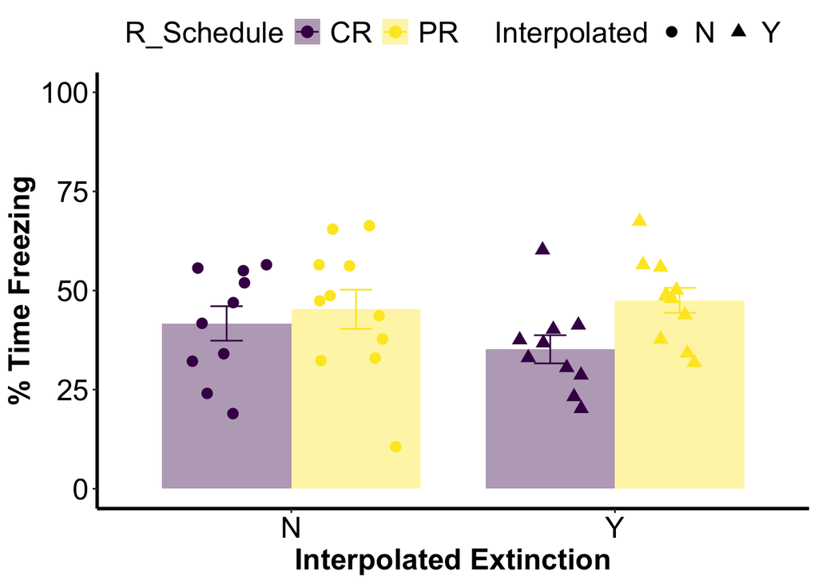

```r
ggplot(FC_ave_1,
       aes(x=Interpolated,
           y=group_mean_freezing,
           group=interaction(R_Schedule, Interpolated),
           color=R_Schedule,
           fill=R_Schedule,
           shape=Interpolated)) +
  scale_fill_viridis(discrete = TRUE) +
  scale_colour_viridis(discrete = TRUE) +
  geom_bar(
    stat = "identity",
    position = "dodge",
    width=0.8,
    alpha=0.4,
    color=NA) +
  geom_errorbar(
    aes(
      ymin = group_mean_freezing-se,
      ymax = group_mean_freezing+se,
      width = .2),
    position=position_dodge(width=0.8)
  ) +
  geom_point(
    data=FC_id_1,
    aes(x=Interpolated, y=mean_freezing),
    position = position_jitterdodge(jitter.height=0, jitter.width=0.25,
                                    dodge.width = 0.8),
    size=3
  ) +
  ylim(0,100) +
  theme_bw() +
  theme(legend.text=element_text(size=18),
        legend.title = element_text(size=18),
        legend.position = "top",
        panel.border= element_blank(),
        plot.background = element_blank(),
        plot.title = element_text(size = 18,face="bold.italic", hjust=0.5),
        panel.grid.major = element_blank(),
        panel.grid.minor = element_blank(),
        axis.text.x = element_text(size = 18, color="black"),
        axis.text.y = element_text(size = 18, color="black"),
        axis.title.x = element_text(size = 18, face= "bold"),
        axis.title.y = element_text(size = 18, face="bold"),
        axis.line.x = element_line(color="black", size = 1),
        axis.line.y = element_line(color="black", size = 1),
        strip.text = element_text(size = 18)) +
  labs(
    x = "Interpolated Extinction",
    y = "% Time Freezing")
```

### E - Stats

Sex was originally in the statistical model: mean_freezing ~ Contingency (2) X CS_time (2) X Sex (2). However, considering broad lack of sex-specific effects, it was dropped from models.

```r
m4e <- FC_id_1 %>%
  aov_ez(id = "id",
         dv = "mean_freezing",
         between = c("R_Schedule", "Interpolated"),
         data = .)
```

```
## Converting to factor: R_Schedule, Interpolated
```

```
## Contrasts set to contr.sum for the following variables: R_Schedule, Interpolated
```

```r
#ANOVA table
nice_m4e <-nice(m4e)
kable(nice_m4e, caption = '<b>Figure 4E: Main FX</b>') %>%
  kable_styling(bootstrap_options = "striped", full_width = F, position = "left")
```

**Figure 4E: Main FX**

| Effect | df | MSE | F | ges | p.value |
| --- | --- | --- | --- | --- | --- |
| R_Schedule | 1, 38 | 174.21 | 3.82 + | .091 | .058 |
| Interpolated | 1, 38 | 174.21 | 0.27 | .007 | .605 |
| R_Schedule:Interpolated | 1, 38 | 174.21 | 1.16 | .030 | .288 |

## F. Extinction Acquisition

### F - Tidy dataframe

```r
bin1 =c("tone 01", "tone 02", "tone 03")
bin2 =c("tone 04", "tone 05", "tone 06")
bin3 =c("tone 07", "tone 08", "tone 09")
bin4 =c("tone 10", "tone 11", "tone 12")

EXT_bin_id_1 <- df %>%
  filter(str_detect(Experiment, "E"),
         str_detect(Experiment, "IPE", negate = TRUE)) %>%
  mutate(Bin = ifelse(Component.Name %in% "pre-tone", "Pre",
                      ifelse(Component.Name %in% bin1, "1",
                             ifelse(Component.Name %in% bin2, "2",
                                    ifelse(Component.Name %in% bin3, "3",
                                           ifelse(Component.Name %in% bin4, "4", "Post")))))) %>%
  group_by(Exp_Type, id, R_Schedule, Interpolated, Bin) %>%
  summarize(mean_freezing=mean(Pct.Component.Time.Freezing), n=n(),
            se=sd(Pct.Component.Time.Freezing/sqrt(n())))
```

```
## 'Interpolated'. You can override using the `.groups` argument.
```

```r
EXT_bin_ave_1 <- EXT_bin_id_1 %>%
  group_by(Exp_Type, R_Schedule, Interpolated, Bin) %>%
  summarize(group_mean_freezing=mean(mean_freezing), n=n(),
            se=sd(mean_freezing/sqrt(n())))
```

```
## You can override using the `.groups` argument.
```

```r
EXT_bin_ave_1$Bin <- factor(EXT_bin_ave_1$Bin, levels = c("Pre", "1", "2", "3", "4", "Post"))
```

### F - Graph

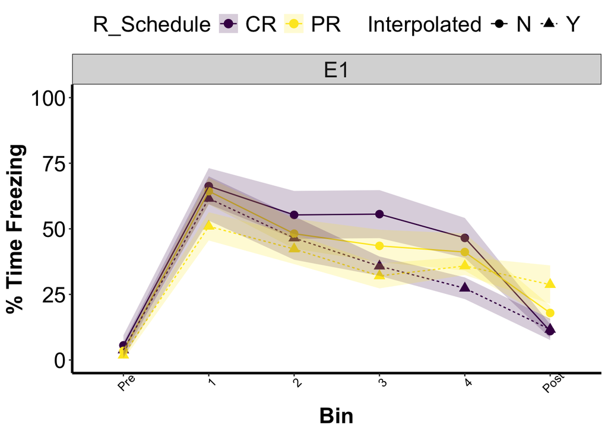

```r
ggplot(
  data = subset(EXT_bin_ave_1, !is.na(Bin)),
  aes(x=Bin,
      y=group_mean_freezing,
      group = interaction(R_Schedule, Interpolated),
      color = R_Schedule,
      fill = R_Schedule,
      shape=Interpolated)) +
  scale_fill_viridis(discrete = TRUE) +
  scale_colour_viridis(discrete = TRUE) +
  facet_wrap(
    vars(Exp_Type)
  ) +
  geom_point(
    size = 3
  ) +
  geom_line(aes(linetype= Interpolated)
  ) +
  ylim(0,100) +
  geom_ribbon(
    aes(
      ymin = group_mean_freezing-se,
      ymax = group_mean_freezing+se),
    alpha = .2,
    color = NA
  ) +
  theme_bw() +
  theme(legend.text=element_text(size=18),
        legend.title = element_text(size=18),
        legend.position = "top",
        panel.border= element_blank(),
        plot.background = element_blank(),
        plot.title = element_text(size = 18,face="bold.italic", hjust=0.5),
        panel.grid.major = element_blank(),
        panel.grid.minor = element_blank(),
        axis.text.x = element_text(size = 10, color="black", angle = 45),
        axis.text.y = element_text(size = 18, color="black"),
        axis.title.x = element_text(size = 18, face= "bold"),
        axis.title.y = element_text(size = 18, face="bold"),
        axis.line.x = element_line(color="black", linewidth = 1),
        axis.line.y = element_line(color="black", linewidth = 1),
        strip.text = element_text(size = 18)) +
  labs(
    x = "Bin",
    y = "% Time Freezing")
```

### F - Stats (ANOVA statistical analyses are represented in figs 1D-E )

```r
###### FE1 ############
m4c <- EXT_bin_id_1 %>%
  filter(str_detect(Bin, "Pre|Post", negate = TRUE)) %>%
  aov_ez(id = "id",
         dv = "mean_freezing",
         between = c("R_Schedule", "Interpolated"),
         within = c("Bin"),
         data = .)
```

```
## Converting to factor: R_Schedule, Interpolated
```

```
## Contrasts set to contr.sum for the following variables: R_Schedule, Interpolated
```

```r
#ANOVA table
nice_m4c <-nice(m4c)
kable(nice_m4c, caption = '<b>Figure 4F: Main FX</b>') %>%
  kable_styling(bootstrap_options = "striped", full_width = F, position = "left")
```

**Figure 4F: Main FX**

| Effect | df | MSE | F | ges | p.value |
| --- | --- | --- | --- | --- | --- |
| R_Schedule | 1, 32 | 845.53 | 0.85 | .015 | .365 |
| Interpolated | 1, 32 | 845.53 | 4.96 * | .085 | .033 |
| R_Schedule:Interpolated | 1, 32 | 845.53 | 0.17 | .003 | .680 |
| Bin | 2.67, 85.53 | 214.32 | 18.23 *** | .187 | <.001 |
| R_Schedule:Bin | 2.67, 85.53 | 214.32 | 0.79 | .010 | .490 |
| Interpolated:Bin | 2.67, 85.53 | 214.32 | 0.60 | .008 | .596 |
| R_Schedule:Interpolated:Bin | 2.67, 85.53 | 214.32 | 1.05 | .013 | .371 |

```r
#Simple contrasts for Contingency
n4c <- emmeans(m4c, ~ Interpolated*Bin)
n4c_pairs <- pairs(n4c, simple="each")
n4c_pairs
```

```
## $`simple contrasts for Interpolated`
## Bin = X1:
##  contrast estimate   SE df t.ratio p.value
##  N - Y        9.05 6.34 32   1.426  0.1635
##
## Bin = X2:
##  contrast estimate   SE df t.ratio p.value
##  N - Y        7.33 7.05 32   1.039  0.3064
##
## Bin = X3:
##  contrast estimate   SE df t.ratio p.value
##  N - Y       15.64 6.27 32   2.496  0.0179
##
## Bin = X4:
##  contrast estimate   SE df t.ratio p.value
##  N - Y       12.25 6.04 32   2.028  0.0510
##
## Results are averaged over the levels of: R_Schedule
##
## $`simple contrasts for Bin`
## Interpolated = N:
##  contrast estimate   SE df t.ratio p.value
##  X1 - X2     13.58 4.12 32   3.301  0.0121
##  X1 - X3     15.76 5.44 32   2.900  0.0322
##  X1 - X4     21.47 5.10 32   4.212  0.0011
##  X2 - X3      2.18 4.92 32   0.443  0.9704
##  X2 - X4      7.88 4.27 32   1.847  0.2709
##  X3 - X4      5.70 4.37 32   1.307  0.5655
##
## Interpolated = Y:
##  contrast estimate   SE df t.ratio p.value
##  X1 - X2     11.87 4.12 32   2.884  0.0335
##  X1 - X3     22.36 5.44 32   4.113  0.0014
##  X1 - X4     24.67 5.10 32   4.840  0.0002
##  X2 - X3     10.49 4.92 32   2.133  0.1644
##  X2 - X4     12.80 4.27 32   2.999  0.0255
##  X3 - X4      2.31 4.37 32   0.529  0.9513
##
## Results are averaged over the levels of: R_Schedule
## P value adjustment: tukey method for comparing a family of 4 estimates
```

```r
kable(n4c_pairs[1], caption = '<b>Figure 4F: Simple Contrasts for Interpolated CS</b>')
```

**Figure 4F: Simple Contrasts for Interpolated CS**

| contrast | Bin | estimate | SE | df | t.ratio | p.value |
| --- | --- | --- | --- | --- | --- | --- |
| N - Y | X1 | 9.048312 | 6.343752 | 32 | 1.426335 | 0.1634558 |
| N - Y | X2 | 7.331667 | 7.053954 | 32 | 1.039370 | 0.3064228 |
| N - Y | X3 | 15.642143 | 6.268096 | 32 | 2.495517 | 0.0179255 |
| N - Y | X4 | 12.249026 | 6.041044 | 32 | 2.027634 | 0.0509934 |

```r
kable(n4c_pairs[2], caption = '<b>Figure 4F: Simple Contrasts for CS-Bin CS</b>')
```

**Figure 4F: Simple Contrasts for CS-Bin CS**

| contrast | Interpolated | estimate | SE | df | t.ratio | p.value |
| --- | --- | --- | --- | --- | --- | --- |
| X1 - X2 | N | 13.583983 | 4.115553 | 32 | 3.3006458 | 0.0120842 |
| X1 - X3 | N | 15.763680 | 5.435238 | 32 | 2.9002738 | 0.0322073 |
| X1 - X4 | N | 21.467814 | 5.096473 | 32 | 4.2122886 | 0.0010530 |
| X2 - X3 | N | 2.179697 | 4.917481 | 32 | 0.4432548 | 0.9704446 |
| X2 - X4 | N | 7.883831 | 4.268914 | 32 | 1.8468001 | 0.2709111 |
| X3 - X4 | N | 5.704134 | 4.365069 | 32 | 1.3067684 | 0.5654737 |
| X1 - X2 | Y | 11.867338 | 4.115553 | 32 | 2.8835341 | 0.0334997 |
| X1 - X3 | Y | 22.357511 | 5.435238 | 32 | 4.1134370 | 0.0013858 |
| X1 - X4 | Y | 24.668528 | 5.096473 | 32 | 4.8403140 | 0.0001779 |
| X2 - X3 | Y | 10.490173 | 4.917481 | 32 | 2.1332412 | 0.1644120 |
| X2 - X4 | Y | 12.801191 | 4.268914 | 32 | 2.9986994 | 0.0254832 |
| X3 - X4 | Y | 2.311017 | 4.365069 | 32 | 0.5294343 | 0.9512931 |

```r
n4c_pairs
```

```
## $`simple contrasts for Interpolated`
## Bin = X1:
##  contrast estimate   SE df t.ratio p.value
##  N - Y        9.05 6.34 32   1.426  0.1635
##
## Bin = X2:
##  contrast estimate   SE df t.ratio p.value
##  N - Y        7.33 7.05 32   1.039  0.3064
##
## Bin = X3:
##  contrast estimate   SE df t.ratio p.value
##  N - Y       15.64 6.27 32   2.496  0.0179
##
## Bin = X4:
##  contrast estimate   SE df t.ratio p.value
##  N - Y       12.25 6.04 32   2.028  0.0510
##
## Results are averaged over the levels of: R_Schedule
##
## $`simple contrasts for Bin`
## Interpolated = N:
##  contrast estimate   SE df t.ratio p.value
##  X1 - X2     13.58 4.12 32   3.301  0.0121
##  X1 - X3     15.76 5.44 32   2.900  0.0322
##  X1 - X4     21.47 5.10 32   4.212  0.0011
##  X2 - X3      2.18 4.92 32   0.443  0.9704
##  X2 - X4      7.88 4.27 32   1.847  0.2709
##  X3 - X4      5.70 4.37 32   1.307  0.5655
##
## Interpolated = Y:
##  contrast estimate   SE df t.ratio p.value
##  X1 - X2     11.87 4.12 32   2.884  0.0335
##  X1 - X3     22.36 5.44 32   4.113  0.0014
##  X1 - X4     24.67 5.10 32   4.840  0.0002
##  X2 - X3     10.49 4.92 32   2.133  0.1644
##  X2 - X4     12.80 4.27 32   2.999  0.0255
##  X3 - X4      2.31 4.37 32   0.529  0.9513
##
## Results are averaged over the levels of: R_Schedule
## P value adjustment: tukey method for comparing a family of 4 estimates
```

## Not Shown Interpolated extinction session

### Not Shown - Tidy dataframe

```r
bin1 =c("tone 01", "tone 02", "tone 03", "tone 04", "tone 05")
bin2 =c("tone 06", "tone 07", "tone 08", "tone 09","tone 10")
bin3 =c("tone 11", "tone 12","tone 13", "tone 14", "tone 15" )
bin4 =c("tone 16", "tone 17","tone 18", "tone 19", "tone 20" )

EXT_bin_id_1 <- df %>%
  filter(str_detect(Experiment, "IPE"),
         str_detect(Experiment, "E1", negate = TRUE)) %>%
  mutate(Bin = ifelse(Component.Name %in% "pre-tone", "Pre",
                      ifelse(Component.Name %in% bin1, "1",
                             ifelse(Component.Name %in% bin2, "2",
                                    ifelse(Component.Name %in% bin3, "3",
                                           ifelse(Component.Name %in% bin4, "4", "Post")))))) %>%
  group_by(Exp_Type, id, R_Schedule, Interpolated, Bin) %>%
  summarize(mean_freezing=mean(Pct.Component.Time.Freezing), n=n(),
            se=sd(Pct.Component.Time.Freezing/sqrt(n())))
```

```
## 'Interpolated'. You can override using the `.groups` argument.
```

```r
EXT_bin_ave_1 <- EXT_bin_id_1 %>%
  group_by(Exp_Type, R_Schedule, Interpolated, Bin) %>%
  summarize(group_mean_freezing=mean(mean_freezing), n=n(),
            se=sd(mean_freezing/sqrt(n())))
```

```
## You can override using the `.groups` argument.
```

```r
EXT_bin_ave_1$Bin <- factor(EXT_bin_ave_1$Bin, levels = c("Pre", "1", "2", "3", "4", "Post"))
```

### Not Shown - Graph

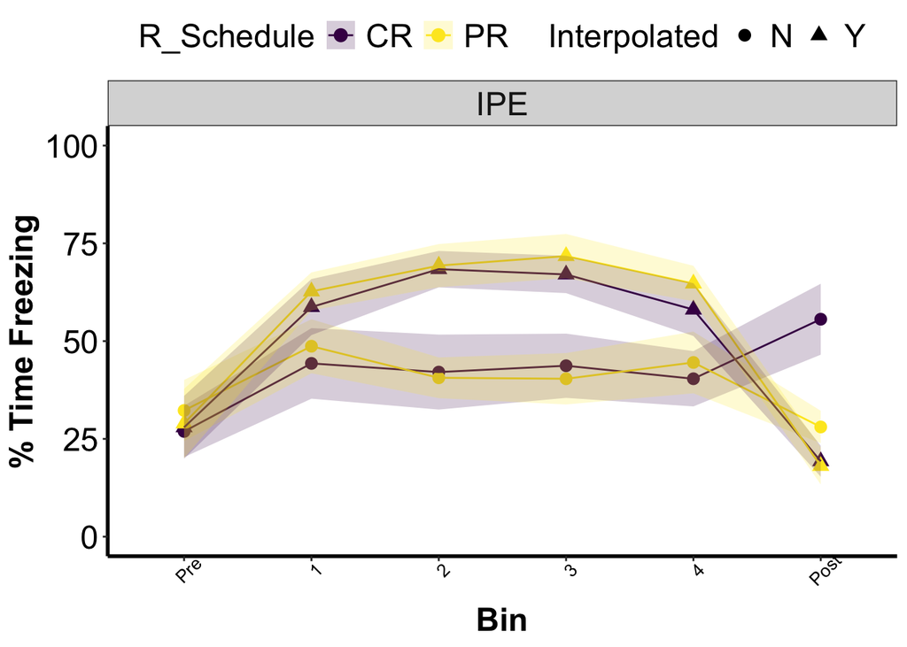

```r
ggplot(
  data = subset(EXT_bin_ave_1, !is.na(Bin)),
  aes(x=Bin,
      y=group_mean_freezing,
      group = interaction(R_Schedule, Interpolated),
      color = R_Schedule,
      fill = R_Schedule,
      shape=Interpolated)) +
  scale_fill_viridis(discrete = TRUE) +
  scale_colour_viridis(discrete = TRUE) +
  facet_wrap(
    vars(Exp_Type)
  ) +
  geom_point(
    size = 3
  ) +
  geom_line(
  ) +
  ylim(0,100) +
  geom_ribbon(
    aes(
      ymin = group_mean_freezing-se,
      ymax = group_mean_freezing+se),
    alpha = .2,
    color = NA
  ) +
  theme_bw() +
  theme(legend.text=element_text(size=18),
        legend.title = element_text(size=18),
        legend.position = "top",
        panel.border= element_blank(),
        plot.background = element_blank(),
        plot.title = element_text(size = 18,face="bold.italic", hjust=0.5),
        panel.grid.major = element_blank(),
        panel.grid.minor = element_blank(),
        axis.text.x = element_text(size = 10, color="black", angle = 45),
        axis.text.y = element_text(size = 18, color="black"),
        axis.title.x = element_text(size = 18, face= "bold"),
        axis.title.y = element_text(size = 18, face="bold"),
        axis.line.x = element_line(color="black", linewidth = 1),
        axis.line.y = element_line(color="black", linewidth = 1),
        strip.text = element_text(size = 18)) +
  labs(
    x = "Bin",
    y = "% Time Freezing")
```